# Geography-independent mucosal microbiota alterations in primary sclerosing cholangitis persist after liver transplantation

5. Hypothesis: PSC disease is associated with fecal calprotectin

# 1 Introduction

## 1.1 About

- Alpha diversity –> group effect, country effect, interaction effect
- Beta diversity – PERMANOVA, PCA -> group effect, country effect, interaction effect
- DAA ->
  - o Group effect – linDA + MaAsLin2 intersection
  - o Country effect – – taxa with significant interaction effect were excluded based on individual post-hoc analysis. Taxa had to have the same direction in both countries

*Importing libraries and custom functions built for this analysis*

```r
source("custom_functions.R")
```

## 1.2 Data Import

Importing ASV, taxa and metadata tables for both Czech and Norway samples.

**Czech**

*MICROBIOME*

```r
path = "../../../../data/analysis_ready_data/ikem/"
asv_tab_ikem <- as.data.frame(fread(file.path(path,"asv_table_ikem.csv"),
                                    check.names = FALSE))
taxa_tab_ikem <- as.data.frame(fread(file.path(path,"taxa_table_ikem.csv"),
                                     check.names = FALSE))
metadata_ikem <- as.data.frame(fread(file.path(path,"metadata_ikem.csv"),
                                     check.names = FALSE))
```

*Fecal calprotectin info*

```r
# clinical metadata
metadata_clinical <- read.csv("../../../../data/clinical_data/clinical_metadata_cz.csv")
metadata_clinical$PatientID <- as.character(metadata_clinical$PatientID)
```

**Norway**

*MICROBIOME*

```r
path = "../../../../data/analysis_ready_data/norway/"
asv_tab_norway <- as.data.frame(fread(file.path(path,"asv_table_norway.csv"),
                                    check.names = FALSE))
taxa_tab_norway <- as.data.frame(fread(file.path(path,"taxa_table_norway.csv"),
                                    check.names = FALSE))
metadata_norway <- as.data.frame(fread(file.path(path,"metadata_norway.csv"),
                                    check.names = FALSE))
```

*Fecal calprotectin info*

```r
# clinical metadata
metadata_clinical_no <- read.csv("../../../../data/clinical_data/clinical_metadata_no.csv")
metadata_clinical_no$PatientID <- paste0("NO_", as.character(metadata_clinical_no$subjectid))
```

### 1.2.1 Merging

**Clinical data**

```r
metadata_ikem <- merge(metadata_ikem,metadata_clinical[,c("SampleID","Fecal.calprotectin")],by="SampleID",all.x=TRUE) %>%
  dplyr::mutate(Calprotectin=Fecal.calprotectin) %>%
  dplyr::mutate(Calprotectin = case_when(
        Calprotectin == ">6000" ~ "6000",
        TRUE ~ Calprotectin)) %>%
  dplyr::mutate(Calprotectin= as.numeric(Calprotectin))

metadata_norway <- merge(metadata_norway,metadata_clinical_no[,c("SampleID","Calprotectin")],
                         by="SampleID",all.x=TRUE) %>%
  dplyr::mutate(Calprotectin= as.numeric(Calprotectin))
```

**Terminal ileum**

```r
ileum_data <- merging_data(asv_tab_1=asv_tab_ikem,
                           asv_tab_2= asv_tab_norway,
                           taxa_tab_1=taxa_tab_ikem,
                           taxa_tab_2=taxa_tab_norway,
                           metadata_1=metadata_ikem,
                           metadata_2=metadata_norway,
                           segment="TI",Q="Q5")
```

```
Removing 1498 ASV(s)
```

```
Removing 1834 ASV(s)
```

```
Merging at ASV level
```

```
Finding inconsistencies in taxonomy, trying to keep the ones that have better taxonomy assignment
```

```
Removing 2296 ASV(s)
```

```r
ileum_asv_tab <- ileum_data[[1]]
ileum_taxa_tab <- ileum_data[[2]]
ileum_metadata <- ileum_data[[3]]
```

```r
ileum_metadata %<>%  dplyr::mutate(
  log_Calprotectin=log(Calprotectin,base = 10))

median(ileum_metadata$Calprotectin,na.rm = TRUE)
```

```
[1] 84.5
```

```r
median(ileum_metadata$log_Calprotectin,na.rm = TRUE)
```

```
[1] 1.926667
```

```r
p1 <- ggplot(ileum_metadata,aes(log_Calprotectin)) +
  geom_histogram() +
  geom_vline(xintercept = log(250,base=10), linetype="dashed",
               color = "red")
```

*Splitting to groups*

```r
ileum_metadata %<>% dplyr::mutate(Calprotectin_groups = case_when(
    Calprotectin <= 250 ~ "low",
    Calprotectin > 250 ~ "high"))

ileum_metadata %>% group_by(Calprotectin_groups) %>%
  count()
```

```
# A tibble: 3 × 2
# Groups:   Calprotectin_groups [3]
  Calprotectin_groups     n
  <chr>               <int>
1 high                   32
2 low                    62
3 <NA>                   14
```

```r
p2 <- ggplot(ileum_metadata %>% dplyr::filter(!is.na(Calprotectin_groups)),aes(Calprotectin_groups)) +
  geom_bar()
```

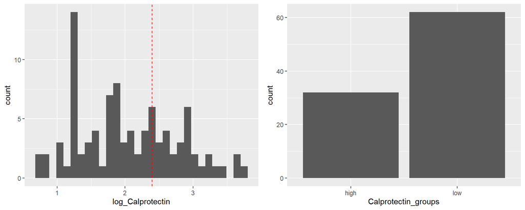

```r
p <- ggarrange(p1,p2,ncol = 2)
p
```

```r
ileum_metadata %<>% drop_na(Calprotectin) %>% dplyr::filter(Group!="healthy")
ileum_asv_tab %<>% dplyr::select("SeqID",ileum_metadata$SampleID)
ileum_taxa_tab %<>% dplyr::filter(SeqID %in% ileum_asv_tab$SeqID)
```

**Colon**

```r
colon_data <- merging_data(asv_tab_1=asv_tab_ikem,
                           asv_tab_2=asv_tab_norway,
                           taxa_tab_1=taxa_tab_ikem,
                           taxa_tab_2=taxa_tab_norway,
                           metadata_1=metadata_ikem,
                           metadata_2=metadata_norway,
                           segment="colon",Q="Q5")
```

```
Removing 739 ASV(s)
```

```
Removing 266 ASV(s)
```

```
Merging at ASV level
```

```
Finding inconsistencies in taxonomy, trying to keep the ones that have better taxonomy assignment
```

```
Removing 2852 ASV(s)
```

```r
colon_asv_tab <- colon_data[[1]]
colon_taxa_tab <- colon_data[[2]]
colon_metadata <- colon_data[[3]]
```

```r
colon_metadata %<>%  dplyr::mutate(
  log_Calprotectin=log(Calprotectin,base = 10))

colon_metadata_forplot <- colon_metadata %>%
        group_by(Patient) %>%
        distinct(Patient, .keep_all = TRUE) %>%
        as.data.frame()

median(colon_metadata_forplot$Calprotectin,na.rm = TRUE)
```

```
[1] 79
```

```r
median(colon_metadata_forplot$log_Calprotectin,na.rm = TRUE)
```

```
[1] 1.897488
```

```r
p1 <- ggplot(colon_metadata_forplot,aes(log_Calprotectin)) +
  geom_histogram() +
  geom_vline(xintercept = log(250,base=10), linetype="dashed",
               color = "red")
```

*Splitting to groups*

```r
colon_metadata %<>% dplyr::mutate(Calprotectin_groups = case_when(
    Calprotectin <= 250 ~ "low",
    Calprotectin > 250 ~ "high"))

colon_metadata_forplot %<>% dplyr::mutate(Calprotectin_groups = case_when(
    Calprotectin <= 250 ~ "low",
    Calprotectin > 250 ~ "high"))

colon_metadata_forplot %>% group_by(Calprotectin_groups) %>%
  count()
```

```
# A tibble: 3 × 2
# Groups:   Calprotectin_groups [3]
  Calprotectin_groups     n
  <chr>               <int>
1 high                   37
2 low                    87
3 <NA>                   22
```

```r
p2 <- ggplot(colon_metadata_forplot %>% dplyr::filter(!is.na(Calprotectin_groups)),aes(Calprotectin_groups)) +
  geom_bar()
```

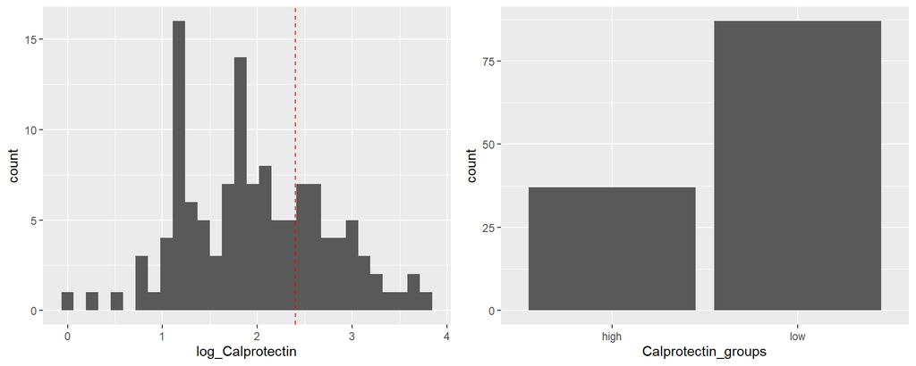

```r
p <- ggarrange(p1,p2,ncol = 2)
p
```

```r
colon_metadata %<>% drop_na(Calprotectin) %>% dplyr::filter(Group!="healthy")

colon_asv_tab %<>% dplyr::select("SeqID",colon_metadata$SampleID)
colon_taxa_tab %<>% dplyr::filter(SeqID %in% colon_asv_tab$SeqID)
```

## 1.3 CHI SQUARE TEST

```r
metadata <- rbind(ileum_metadata,colon_metadata) %>%
        group_by(Patient) %>%
        distinct(Patient, .keep_all = TRUE) %>%
        as.data.frame()
```

```r
df <- metadata %>% dplyr::group_by(Calprotectin_groups,Group) %>%
  distinct(Patient, .keep_all = TRUE) %>%
  count() %>% drop_na()

# Summarize by Nancy and Group
data <- df %>%
  group_by(Calprotectin_groups, Group) %>%
  summarise(n = sum(n), .groups = "drop") %>%
  pivot_wider(names_from = Group, values_from = n) %>%
  column_to_rownames("Calprotectin_groups") %>%
  as.matrix()

chi_res <- chisq.test(data)
data
```

```
     pre_ltx rPSC
high      25   13
low       76   17
```

```r
chi_res$expected
```

```
      pre_ltx     rPSC
high 29.29771  8.70229
low  71.70229 21.29771
```

```r
chi_res
```

```
    Pearson's Chi-squared test with Yates' continuity correction

data:  data
X-squared = 3.0279, df = 1, p-value = 0.08184
```

# 2 Data Analysis - Terminal ileum

```r
segment="terminal_ileum"
```

## 2.1 Filtering

Rules:

- sequencing depth > 10000
- nearZeroVar() with default settings

**Rarefaction Curve**

```r
path="../../../intermediate_files/rarecurves"
seq_depth_threshold <- 10000
```

```r
ps <- construct_phyloseq(ileum_asv_tab,ileum_taxa_tab,ileum_metadata)
rareres <- get_rarecurve(obj=ps, chunks=500)
save(rareres,file = file.path(path,"rarefaction_ileum.Rdata"))
```

```r
load(file.path(path,"rarefaction_ileum.Rdata"))

prare <- ggrarecurve(obj=rareres,
                      factorNames="Country",
                      indexNames=c("Observe")) +
  theme_bw() +
  theme(axis.text=element_text(size=8), panel.grid=element_blank(),
        strip.background = element_rect(colour=NA,fill="grey"),
        strip.text.x = element_text(face="bold")) +
  geom_vline(xintercept = seq_depth_threshold,
             linetype="dashed",
             color = "red") +
  xlim(0, 20000)
```

```
The color has been set automatically, you can reset it manually by adding scale_color_manual(values=yourcolors)
```

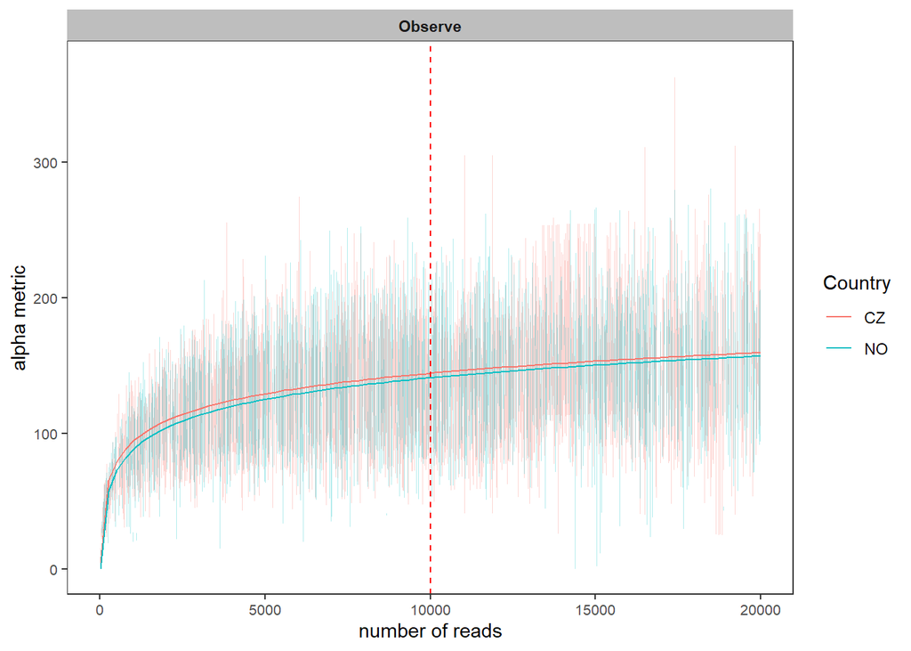

```r
prare
```

**Library size**

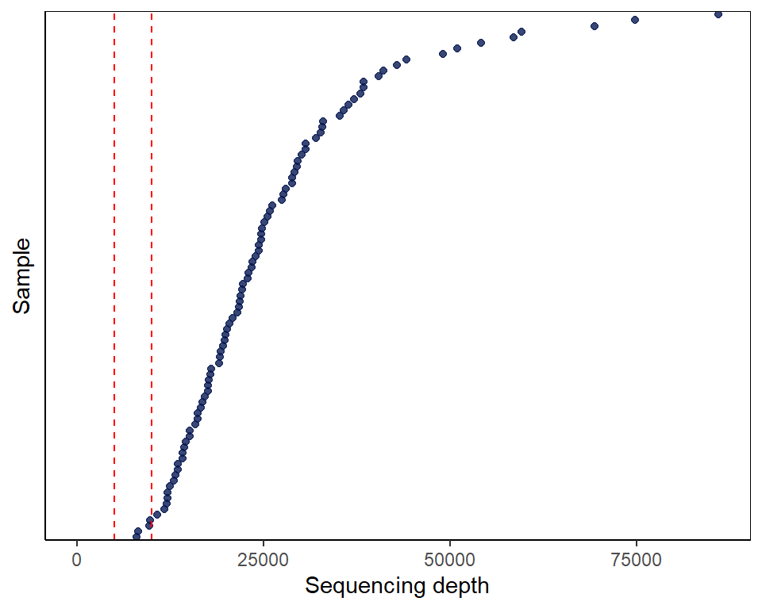

```r
read_counts(ileum_asv_tab, line = c(5000,10000))
```

### 2.1.1 Sequencing depth

```r
data_filt <- seq_depth_filtering(ileum_asv_tab,
                                 ileum_taxa_tab,
                                 ileum_metadata,
                                 seq_depth_threshold = 10000)
```

```
Removing 238 ASV(s)
```

```r
filt_ileum_asv_tab <- data_filt[[1]]; alpha_ileum_asv_tab <- filt_ileum_asv_tab
filt_ileum_taxa_tab <- data_filt[[2]]; alpha_ileum_taxa_tab <- filt_ileum_taxa_tab
filt_ileum_metadata <- data_filt[[3]]; alpha_ileum_metadata <- filt_ileum_metadata

seq_step <- dim(filt_ileum_asv_tab)[1]
```

**Library size**

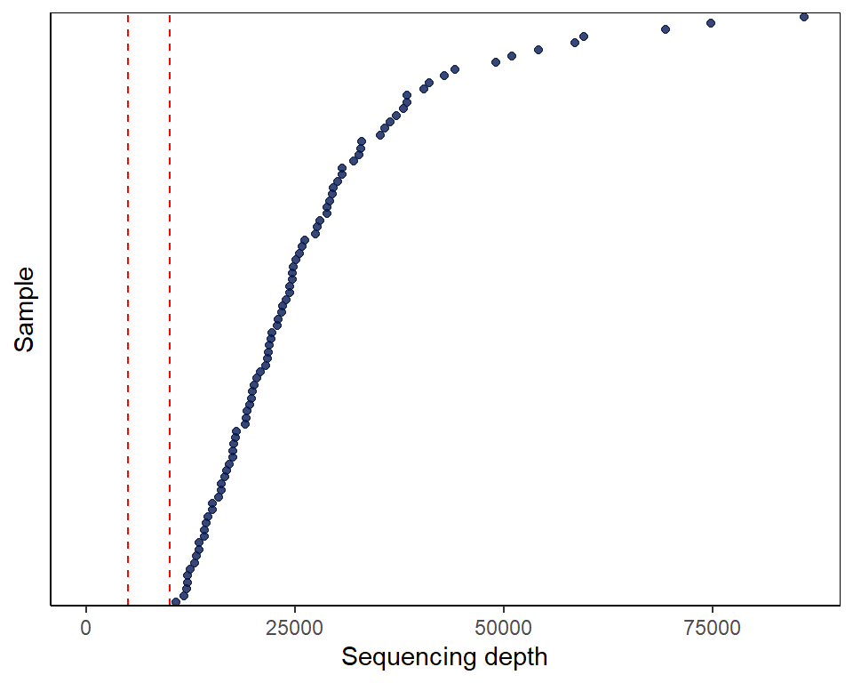

```r
read_counts(filt_ileum_asv_tab,line = c(5000,10000))
```

### 2.1.2 NearZeroVar

```r
data_filt <- nearzerovar_filtering(filt_ileum_asv_tab,
                                   filt_ileum_taxa_tab,
                                   filt_ileum_metadata)

filt_ileum_asv_tab <- data_filt[[1]]
filt_ileum_taxa_tab <- data_filt[[2]]
nearzero_step <- dim(filt_ileum_asv_tab)[1]
```

Library size

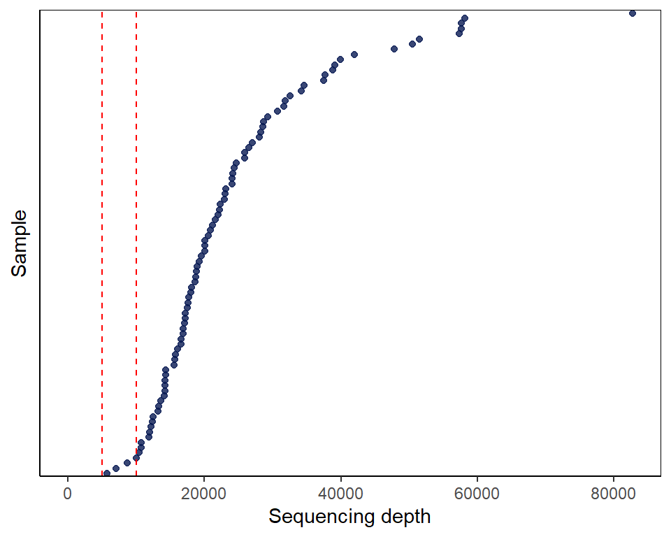

```r
read_counts(filt_ileum_asv_tab,line = c(5000,10000))
```

### 2.1.3 Final Counts

```r
final_counts_filtering(ileum_asv_tab,
                       filt_ileum_asv_tab,
                       filt_ileum_metadata,
                       seq_step, 0, nearzero_step) %>% `colnames<-`("Count")
```

```
                            Count
Raw data: ASVs               2836
Raw data: Samples              94
Sequencing depth filt: ASVs  2598
Prevalence filt: ASVs           0
NearZeroVar filt: ASVs        627
Filt data: ASVs               627
Filt data: Samples             90
Filt data: Patients            90
Filt data: Patients.1           0
Filtered samples                4
Matrices                       TI
healthy                         0
non-rPSC                        0
rPSC                           26
pre_ltx                        64
post_ltx                        0
ETOH                            0
```

## 2.2 Alpha diversity

```r
path = "../../../results/merged_sites/main_analysis/Q5/alpha_diversity"
```

**Calculation**

```r
# Construct MPSE object
alpha_ileum_metadata$Sample <- alpha_ileum_metadata$SampleID
ileum_mpse <- as.MPSE(construct_phyloseq(alpha_ileum_asv_tab,
                                         alpha_ileum_taxa_tab,
                                         alpha_ileum_metadata))

ileum_mpse %<>% mp_rrarefy(raresize = 10000,seed = 123)

# Calculate alpha diversity - rarefied counts
ileum_mpse %<>% mp_cal_alpha(.abundance=RareAbundance, force=TRUE)
```

```r
alpha_div_plots <- list()

# preparing data frame
alpha_data <- data.frame(SampleID=ileum_mpse$Sample.x,
                         Observe=ileum_mpse$Observe,
                         Shannon=ileum_mpse$Shannon,
                         Simpson=ileum_mpse$Simpson,
                         Pielou=ileum_mpse$Pielou,
                         Group=ileum_mpse$Calprotectin_groups,
                         Country=ileum_mpse$Country,
                         Patient=ileum_mpse$Patient)

write.csv(alpha_data,file.path(path,paste0("alpha_indices_",segment,".csv")),
          row.names = FALSE)

alpha_data %<>% drop_na()
```

### 2.2.1 Plots

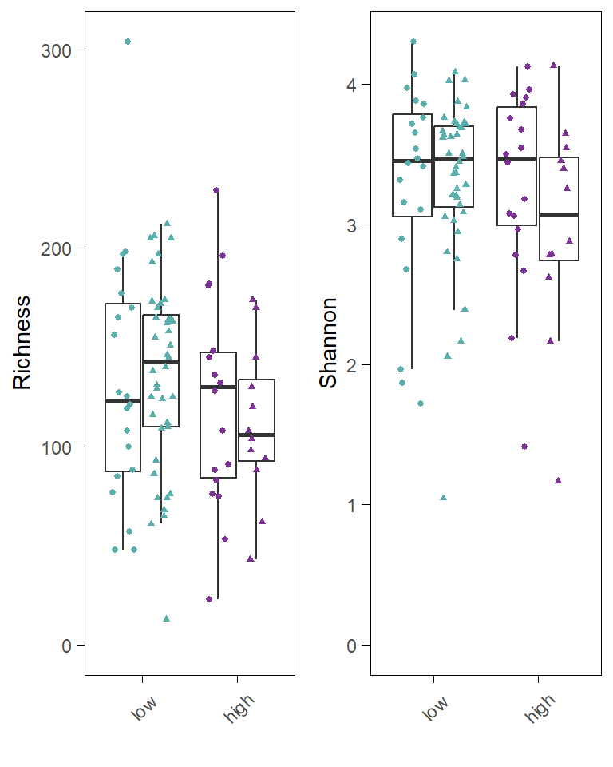

```r
p_boxplot_alpha <- alpha_diversity_countries(alpha_data,
                                             show_legend = FALSE,
                                             size=1,gap=FALSE)
# save the results
alpha_div_plots[[paste(segment,"Country")]] <- p_boxplot_alpha

# see the results
p_boxplot_alpha
```

### 2.2.2 Linear Model

```r
path = "../../../results/merged_sites/main_analysis/Q5/alpha_diversity"
alpha_data <- read.csv(file.path(path,paste0("alpha_indices_",segment,".csv")))
```

**Richness**

```r
results_model <- pairwise.lm(formula = "Observe ~ Group * Country",
                             factors=alpha_data$Group,
                             data=alpha_data)

# check interaction
if (!is.data.frame(results_model)){
  results_model_observe <- results_model[[1]]
  results_model_observe_emeans <- results_model[[2]]
} else {
  results_model_observe <- results_model
  results_model_observe_emeans <- NA
}

# save the results
pc_observed <- list();
pc_observed[[segment]] <- results_model_observe
```

```r
# see the results
knitr::kable(results_model_observe,digits = 3,
caption = "Raw results of linear model of richness estimation.")
```

Raw results of linear model of richness estimation.

|  | Estimate | Std. Error | t value | Pr(>\|t\|) |
| --- | --- | --- | --- | --- |
| low vs Grouphigh | -9.672 | 16.717 | -0.579 | 0.564 |
| low , high - CZ vs NO | 3.275 | 14.092 | 0.232 | 0.817 |
| low vs Grouphigh:CountryNO | -15.219 | 23.797 | -0.640 | 0.524 |

```r
knitr::kable(results_model_observe_emeans,digits = 3,
caption = "Raw results of independent country analysis")
```

Table: Raw results of independent country analysis

**Shannon**

```r
results_model <- pairwise.lm(formula = "Shannon ~ Group * Country",
                             factors=alpha_data$Group,
                             data=alpha_data)

# check interaction
if (!is.data.frame(results_model)){
  results_model_shannon <- results_model[[1]]
  results_model_shannon_emeans <- results_model[[2]]
} else {
  results_model_shannon <- results_model
  results_model_shannon_emeans <- NA
}

# save the results
pc_shannon <- list();
pc_shannon[[segment]] <- as.data.frame(results_model_shannon)
```

```r
# see the results
knitr::kable(results_model_shannon,digits = 3,
caption = "Raw results of linear model of Shannon estimation.")
```

Raw results of linear model of Shannon estimation.

|  | Estimate | Std. Error | t value | Pr(>\|t\|) |
| --- | --- | --- | --- | --- |
| low vs Grouphigh | -0.010 | 0.219 | -0.044 | 0.965 |
| low , high - CZ vs NO | 0.030 | 0.185 | 0.164 | 0.870 |
| low vs Grouphigh:CountryNO | -0.323 | 0.312 | -1.034 | 0.304 |

```r
knitr::kable(results_model_shannon_emeans,digits = 3,
caption = "Raw results of independent country analysis")
```

Table: Raw results of independent country analysis

**Simpson**

```r
results_model <- pairwise.lm(formula = "Simpson ~ Group * Country",
                                     factors=alpha_data$Group,
                                     data=alpha_data)

# check interaction
if (!is.data.frame(results_model)){
  results_model_simpson <- results_model[[1]]
  results_model_simpson_emeans <- results_model[[2]]
} else {
  results_model_simpson <- results_model
  results_model_simpson_emeans <- NA
}


# save the results
pc_simpson <- list();
pc_simpson[[segment]] <- as.data.frame(results_model_simpson)
```

```r
# see the results
knitr::kable(results_model_simpson,digits = 3,
caption = "Raw results of linear model of Simpson estimation.")
```

Raw results of linear model of Simpson estimation.

|  | Estimate | Std. Error | t value | Pr(>\|t\|) |
| --- | --- | --- | --- | --- |
| low vs Grouphigh | 0.000 | 0.029 | -0.001 | 0.999 |
| low , high - CZ vs NO | 0.001 | 0.024 | 0.055 | 0.956 |
| low vs Grouphigh:CountryNO | -0.034 | 0.041 | -0.826 | 0.411 |

```r
knitr::kable(results_model_simpson_emeans,digits = 3,
caption = "Raw results of independent country analysis")
```

Table: Raw results of independent country analysis

### 2.2.3 Saving results

```r
alpha_list <- list(
  Richness=pc_observed[[segment]],
  Shannon=pc_shannon[[segment]])

write.xlsx(alpha_list,
           file = file.path(path,paste0("alpha_diversity_results_",segment,".xlsx")))
```

## 2.3 Beta diversity

### 2.3.1 Main analysis

**Genus level, Aitchison distance**

```r
level="genus"
```

```r
path = "../../../results/merged_sites/main_analysis/Q5/beta_diversity"
```

```r
pairwise_aitchison_raw <- list()
pca_plots_list <- list()
```

Aggregation, filtering

```r
# Aggregation
genus_data <- aggregate_taxa(ileum_asv_tab,
                             ileum_taxa_tab,
                             taxonomic_level=level,
                             names=TRUE)
# Filtration
filt_data <- filtering_steps(genus_data[[1]],
                             genus_data[[2]],
                             ileum_metadata,
                             seq_depth_threshold=10000)
```

```
Removing 17 ASV(s)
```

```r
filt_ileum_genus_tab <- filt_data[[1]]
filt_ileum_genus_taxa <- filt_data[[2]]
filt_ileum_metadata <- filt_data[[3]] %>% dplyr::mutate(Group=Calprotectin_groups)
```

##### 2.3.1.0.1 PERMANOVA

```r
pairwise_df <- filt_ileum_genus_tab %>% column_to_rownames("SeqID") %>% t()

# main effect
pp_main <- pairwise.adonis(pairwise_df,
                           filt_ileum_metadata$Group,
                           covariate = filt_ileum_metadata$Country, sim.method = "robust.aitchison", p.adjust.m="BH")

# interaction
pp_int <- pairwise.adonis(pairwise_df,filt_ileum_metadata$Group,covariate = filt_ileum_metadata$Country, interaction = TRUE, sim.method = "robust.aitchison", p.adjust.m="BH")

# tidy the results
pp_factor <- pp_main[[1]]
pp_cov <- pp_main[[2]]
pp_fac.cov <- pp_int[[3]]

cols <- c("pairs","Df","SumsOfSqs", "F.Model","R2","p.value", "p.adjusted", "sig")
colnames(pp_factor) <- cols; colnames(pp_cov) <- cols; colnames(pp_fac.cov) <- cols;

# save raw results
pairwise_aitchison_raw[[paste(level, segment)]] <- rbind(pp_factor,pp_cov,pp_fac.cov)
```

```r
# see the results
knitr::kable(pp_factor,digits = 3,caption = "PERMANOVA, GROUP separation")
```

PERMANOVA, GROUP separation

| pairs | Df | SumsOfSqs | F.Model | R2 | p.value | p.adjusted | sig |
| --- | --- | --- | --- | --- | --- | --- | --- |
| low vs high | 1 | 186.558 | 1.046 | 0.012 | 0.32 | 0.32 |  |

```r
knitr::kable(pp_cov,digits = 3,caption = "PERMANOVA, COUNTRY separation")
```

PERMANOVA, COUNTRY separation

| pairs | Df | SumsOfSqs | F.Model | R2 | p.value | p.adjusted | sig |
| --- | --- | --- | --- | --- | --- | --- | --- |
| low vs high , Country | 1 | 473.188 | 2.652 | 0.029 | 0.001 | 0.001 | *** |

```r
knitr::kable(pp_fac.cov,digits = 3,caption = "PERMANOVA, INTERACTION GROUP:Country")
```

PERMANOVA, INTERACTION GROUP:Country

| pairs | Df | SumsOfSqs | F.Model | R2 | p.value | p.adjusted | sig |
| --- | --- | --- | --- | --- | --- | --- | --- |
| low vs high : Country | 1 | 171.142 | 0.959 | 0.011 | 0.567 | 0.567 |  |

Interaction check

```r
interaction_sig <- pp_fac.cov$pairs[pp_fac.cov$p.adjusted < 0.1]

if (length(interaction_sig)>0){
  for (i in 1:length(interaction_sig)){
  group1 <- unlist(strsplit(interaction_sig[i],split = " vs "))[1]
  group2 <- unlist(strsplit(interaction_sig[i],split = " vs "))[2]
  group2 <- unlist(strsplit(group2,split = " : "))[1]

  result_list <- adonis_postanalysis(x=pairwise_df,
                      factors = filt_ileum_metadata$v,
                      covariate = filt_ileum_metadata$Country,
                      group1 = group1,
                      group2 = group2)
  print(result_list)
}
}
```

##### 2.3.1.0.2 Plots

**PCA**

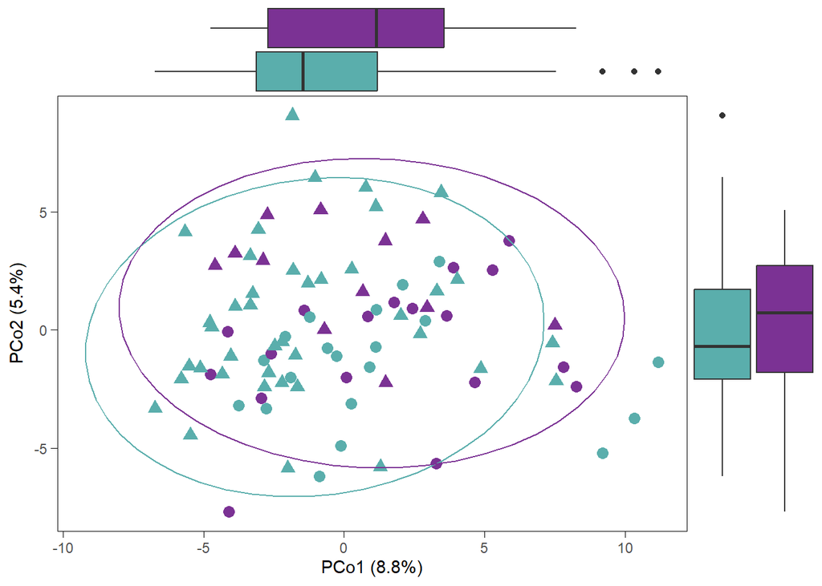

```r
p <- pca_plot_custom(filt_ileum_genus_tab,
                                 filt_ileum_genus_taxa,
                                 filt_ileum_metadata,
                                 show_boxplots = TRUE,
                                 variable = "Group", size=3, show_legend=FALSE)

# save the results
pca_plots_list[[paste(segment,level,"custom")]] <- p

# see the results
p
```

#### 2.3.1.1 Saving results

```r
write.xlsx(pairwise_aitchison_raw[[paste(level, segment)]],
           file = file.path(path,
           paste0("beta_diversity_results_", segment,".xlsx")))
```

## 2.4 Univariate Analysis

### 2.4.1 Main analysis

```r
level="genus"
```

```r
# needed paths
path = "../../../results/merged_sites/main_analysis/Q5/univariate_analysis"
path_maaslin=file.path("../../../intermediate_files/maaslin/Q5",level)
```

```r
# variables
raw_linda_results_genus <- list();
raw_linda_results_genus[[segment]] <- list()
linda_results_genus <- list();
linda_results_genus[[segment]] <- list()

# country and interaction problems
list_intersections <- list()
list_venns <- list()
uni_statistics <- list()

# workbook for final df
wb <- createWorkbook()
```

Aggregate taxa

```r
genus_data <- aggregate_taxa(ileum_asv_tab,
                             ileum_taxa_tab,
                             taxonomic_level = level)

ileum_genus_tab <- genus_data[[1]]
ileum_genus_taxa_tab <- genus_data[[2]]

ileum_genus_asv_taxa_tab <- create_asv_taxa_table(ileum_genus_tab,
                                                  ileum_genus_taxa_tab)
```

#### 2.4.1.1 low vs high

```r
group <- c("low","high")
comparison_name <- paste0(group[1], " vs ",group[2])
```

##### 2.4.1.1.1 linDA

```r
ileum_metadata %<>% dplyr::mutate(Group=Calprotectin_groups)

# prepare the data
linda_data <- binomial_prep(ileum_genus_tab,
                            ileum_genus_taxa_tab,
                            ileum_metadata,
                            group, usage="linDA")
```

```
Removing 11 ASV(s)
```

```
Removing 6 ASV(s)
```

```r
filt_ileum_uni_data <- linda_data[[1]]
filt_ileum_uni_taxa <- linda_data[[2]]
filt_ileum_uni_metadata <- linda_data[[3]]

# fit the model
linda.obj <- linda(filt_ileum_uni_data,
                   filt_ileum_uni_metadata,
                   formula = '~ Group * Country')
```

```
0  features are filtered!
The filtered data has  90  samples and  202  features will be tested!
Imputation approach is used.
Fit linear models ...
Completed.
```

```r
linda.output <- linda.obj$output
linda.output <- linda_renaming(linda.output, group)

# save the results
group1 <- paste0(group[1], " vs ","Group",group[2])
group2 <- paste0(group[1], " , ",group[2], " - CZ vs NO")
group3 <- paste0(group[1], " vs ","Group",group[2], ":CountryNO")

for (grp in c(group1,group2,group3)){
  raw_linda_results_genus[[segment]][[grp]] <-
    rawlinda.df(linda.output,
                grp,
                filt_ileum_uni_data,
                filt_ileum_uni_taxa)

  linda_results_genus[[segment]][[grp]] <-
    linda.df(linda.output,
             grp,
             filt_ileum_uni_data,
             filt_ileum_uni_taxa)
}
```

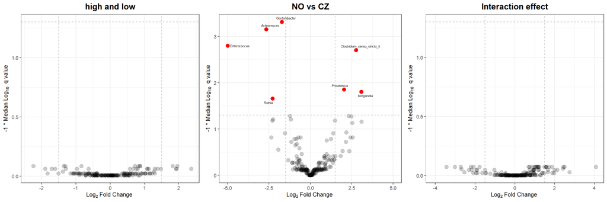

```r
# volcano plot
volcano_1 <- volcano_plot_linda(linda.output,
                                group1,
                                taxa_table = filt_ileum_uni_taxa) +
            ggtitle(comparison_title)

volcano_2  <- volcano_plot_linda(linda.output, group2,
                                taxa_table = filt_ileum_uni_taxa) +
            ggtitle("NO vs CZ")

volcano_3 <- volcano_plot_linda(linda.output, group3,
                                taxa_table = filt_ileum_uni_taxa) +
            ggtitle("Interaction effect")

volcano <- ggarrange(volcano_1,volcano_2,volcano_3, ncol=3)
volcano
```

##### 2.4.1.1.2 MaAsLin2

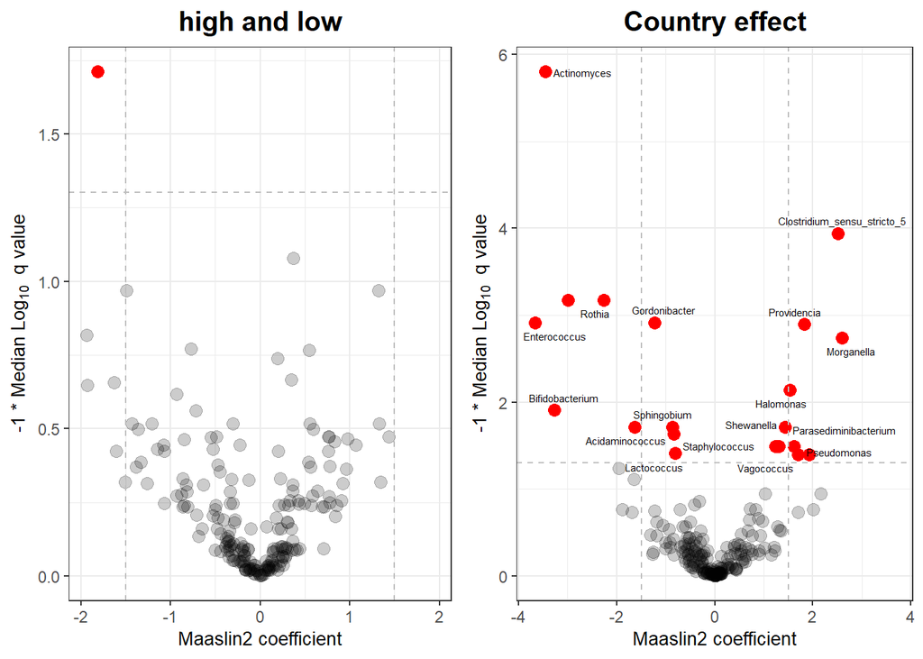

```r
volcano1 <- volcano_plot_maaslin(fit_data,filt_ileum_uni_taxa) +
            ggtitle(comparison_title)

volcano2 <- volcano_plot_maaslin(fit_data,filt_ileum_uni_taxa,variable="Country") +
            ggtitle("Country effect")

volcano <- ggarrange(volcano1,volcano2, ncol=2)
volcano
```

##### 2.4.1.1.3 Group - Intersection

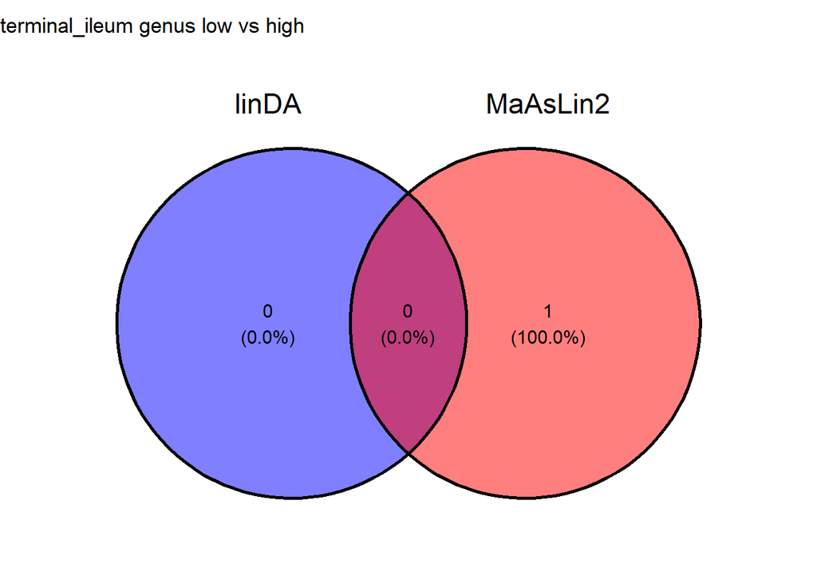

```r
intersection_results <- group_intersection(group, list_intersections, list_venns,
                                           linda.output, fit_data,
                                           raw_linda_results_genus,
                                           segment = segment,
                                           level=level)

list_intersections <- intersection_results[[1]]
list_venns <- intersection_results[[2]]
venn <- intersection_results[[3]]

# show the results
venn
```

##### 2.4.1.1.4 Interaction effect

```r
list_interaction_significant <- country_interaction(group,
                                                    linda.output,
                                                    list_intersections,
                                          filt_ileum_uni_data,
                                          filt_ileum_uni_metadata,
                                          segment=segment,
                                          level=level)

# see the result
## significant interaction effect
list_interaction_significant[[1]]
```

```r
## results for czech cohort
list_interaction_significant[[2]]
```

```
[1] NA
```

```r
## results for norwegian cohort
list_interaction_significant[[3]]
```

```
[1] NA
```

Removing problematic taxa

```r
list_intersections <- removing_interaction_problems(group,
                                                    list_interaction_significant,
                                                    list_intersections,
                                                    segment=segment,
                                                    level=level)
```

##### 2.4.1.1.5 Basic statistics

```r
uni_df <-  merge(basic_univariate_statistics(linda_data,group),
                 raw_linda_results_genus[[segment]][[group1]],
                 by="SeqID",all=TRUE)
```

```
[1] "low"
[1] "high"
[1] "low"
[1] "high"
```

```r
uni_df[["final_sig"]] <- uni_df$SeqID %in% list_intersections[[paste(segment,level,comparison_name)]][["SeqID"]]
uni_statistics[[segment]][[paste(level,comparison_name)]] <- uni_df

# for comparison
new_name <- comparison_name
addWorksheet(wb, sheetName = new_name)
writeData(wb, sheet = new_name, uni_df, rowNames=FALSE)
```

#### 2.4.1.2 Visualization

Heatmap visualizing the linDA’s logFoldChange for taxa with p < 0.1.

```r
list_heatmap <- list_intersections[grep(paste(segment,level),
                                  names(list_intersections),value=TRUE)]

if (length((list_heatmap[[1]][[1]]))>1){
  p_heatmap_linda <- heatmap_linda(list_heatmap,ileum_taxa_tab)
  p_heatmap_linda
}
```

Dotheatmap

```r
if (length((list_heatmap[[1]][[1]]))>0){
dotheatmap_linda <- dot_heatmap_linda(list_heatmap,
                                      uni_statistics$terminal_ileum[grepl(level,names(uni_statistics$terminal_ileum))],
                                      ileum_taxa_tab)
dotheatmap_linda

}
```

**Horizontal bar plot**

```r
if (length((list_heatmap[[1]][[1]]))>0){
p_prevalence <- horizontal_barplot(wb,taxa=levels(dotheatmap_linda$data$SeqID))

p_prevalence_final <- ggarrange(p_prevalence,
                                ggplot() + theme_minimal(),
                                nrow = 2,heights = c(1,0.085))
p <- ggarrange(dotheatmap_linda + theme(legend.position = "none"),p_prevalence_final,ncol=2,widths = c(1,0.2))
p
}
```

#### 2.4.1.3 Saving results

```r
# ALL DATA
saveWorkbook(wb,file.path(path,paste0("uni_analysis_wb_",segment,".xlsx")),
             overwrite = TRUE)

# SIGNIFICANT taxa

write.xlsx(list_intersections[grepl(segment,names(list_intersections))] %>%
            `names<-`(gsub(segment, "", names(
              list_intersections[grepl(segment,names(list_intersections))]))),
           file.path(path,paste0("significant_taxa_",segment,".xlsx")))
```

## 2.5 Machine learning

```r
path = "../../../results/merged_sites/main_analysis/Q5/models"
```

### 2.5.1 ElasticNet

```r
model="enet"
```

#### 2.5.1.1 ASV level

```r
level="ASV"
```

##### 2.5.1.1.1 low vs high

```r
group <- c("low","high")
comparison_name <- paste0(group[1], " vs ",group[2])
```

```r
model_name <- paste(comparison_name,level,segment)

# prepare the data
filt_ileum_uni_data <- binomial_prep(ileum_asv_tab,
                                     ileum_taxa_tab,
                                     ileum_metadata,
                                     group, usage="ml_clr")
```

```
Removing 167 ASV(s)
```

```
Removing 71 ASV(s)
```

```r
# fit the model
enet_model <- glmnet_binomial(filt_ileum_uni_data,
                              sample_method = "atypboot",
                              outcome="Group",
                              N=10,
                              reuse=TRUE,
                              file=model_name,
                              Q="Q5")

# ROC curve
roc_c <- roc_curve(enet_model, group)

# save the results
models_summ <- list()
models_cm <- list()
betas <- list()
roc_cs <- list()

models_summ[[model_name]] <- enet_model$model_summary
models_cm[[model_name]] <- enet_model$conf_matrices$original
roc_cs[[model_name]] <- enet_model$kfold_rocobjs
betas[[model_name]] <- as.matrix(enet_model$betas)

# see the results
enet_model$model_summary %>% t()
```

```
                                     [,1]
alpha                           0.0000000
lambda                          9.3347781
auc                             0.9694444
auc_czech                       0.9638889
auc_no                          0.9729167
auc_optimism_corrected          0.6255978
auc_optimism_corrected_CIL      0.4005091
auc_optimism_corrected_CIU      0.7861538
accuracy                        0.6777778
accuracy_czech                        NaN
accuracy_no                     0.7692308
accuracy_optimism_corrected     0.6413384
accuracy_optimism_corrected_CIL 0.4346841
accuracy_optimism_corrected_CIU 0.7214410
```

```r
enet_model$conf_matrices
```

```
$original
    Predicted
True  0  1
   0  1 29
   1  0 60

$czech
    Predicted
True  0  1
   0  1 17
   1  0 20

$no
   1
0 12 0
1 40 0
```

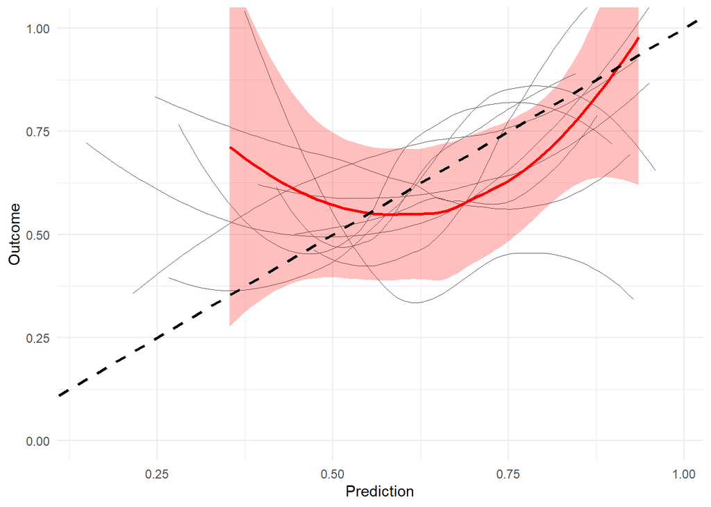

```r
enet_model$plot
```

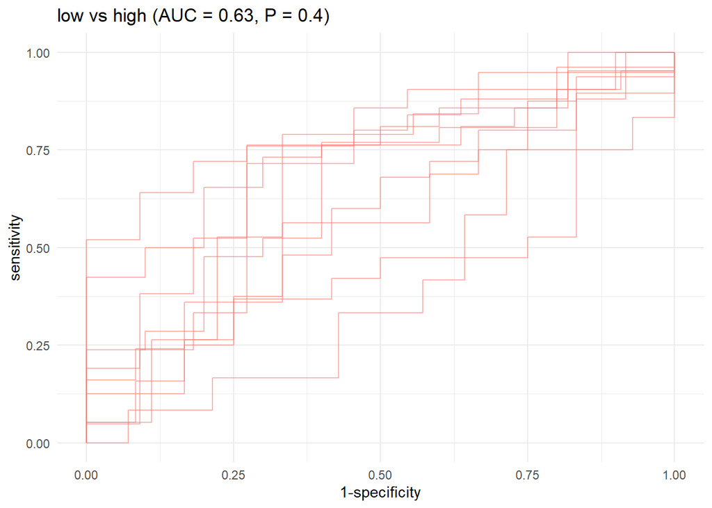

```r
roc_c
```

#### 2.5.1.2 Genus level

```r
level="genus"
```

Aggregate taxa

```r
genus_data <- aggregate_taxa(ileum_asv_tab,
                             ileum_taxa_tab,
                             taxonomic_level = level)

ileum_genus_tab <- genus_data[[1]]
ileum_genus_taxa_tab <- genus_data[[2]]
```

##### 2.5.1.2.1 low vs high

```r
group <- c("low","high")
comparison_name <- paste0(group[1], " vs ",group[2])
```

```r
model_name <- paste(comparison_name,level,segment)

# prepare the data
filt_ileum_uni_data <- binomial_prep(ileum_genus_tab,
                                     ileum_genus_taxa_tab,
                                     ileum_metadata,
                                     group,
                                     usage="ml_clr")
```

```
Removing 11 ASV(s)
```

```
Removing 6 ASV(s)
```

```r
# fit the model
enet_model <- glmnet_binomial(filt_ileum_uni_data,
                              sample_method = "atypboot",
                              outcome="Group",
                              N=10,
                              reuse=TRUE,
                              file=model_name,
                              Q="Q5")

# ROC
roc_c <- roc_curve(enet_model, group)

# save the results
models_summ[[model_name]] <- enet_model$model_summary
models_cm[[model_name]] <- enet_model$conf_matrices$original
roc_cs[[model_name]] <- enet_model$kfold_rocobjs
betas[[model_name]] <- as.matrix(enet_model$betas)

# see the results
enet_model$model_summary %>% t()
```

```
                                     [,1]
alpha                           0.0000000
lambda                          0.1511817
auc                             0.9420571
auc_czech                       0.8925971
auc_no                          0.9579125
auc_optimism_corrected          0.6199997
auc_optimism_corrected_CIL      0.5498124
auc_optimism_corrected_CIU      0.6872995
accuracy                        0.8465909
accuracy_czech                        NaN
accuracy_no                     0.9027356
accuracy_optimism_corrected     0.6540349
accuracy_optimism_corrected_CIL 0.5724537
accuracy_optimism_corrected_CIU 0.7100395
```

```r
enet_model$conf_matrices
```

```
$original
    Predicted
True   0   1
   0  90  67
   1  14 357

$czech
    Predicted
True  0  1
   0 62 41
   1  8 88

$no
    Predicted
True   0   1
   0  28  26
   1   6 269
```

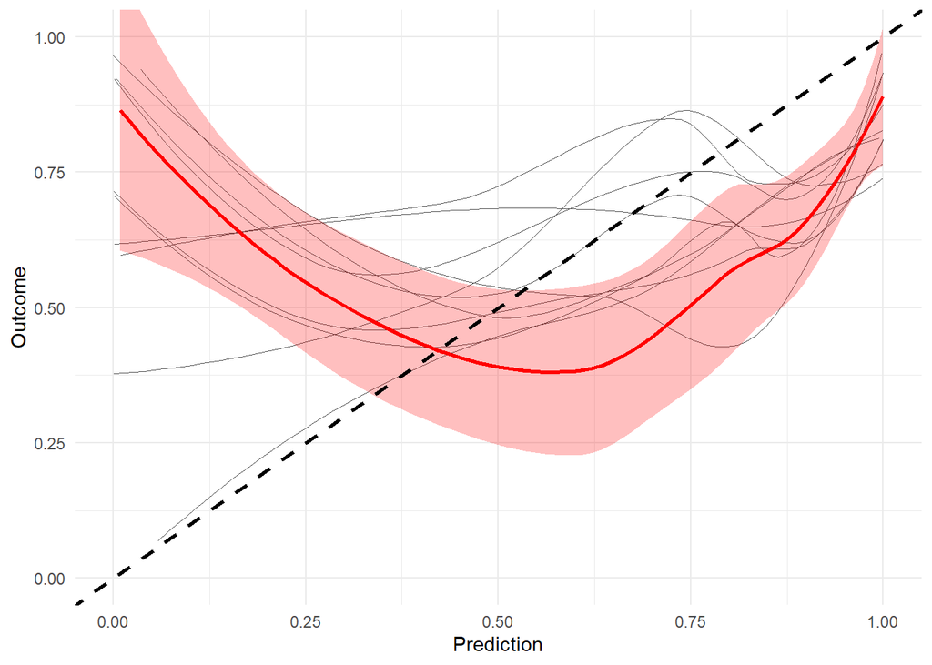

```r
enet_model$plot
```

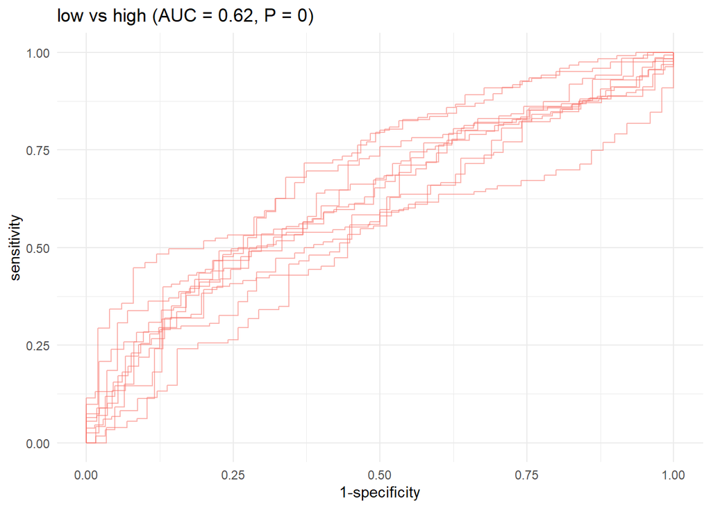

```r
roc_c
```

#### 2.5.1.3 Saving results

```r
models_summ_df_ileum <- do.call(rbind,
  models_summ[grep(segment,names(models_summ),value = TRUE)])

write.csv(models_summ_df_ileum,file.path(path,paste0("elastic_net_",segment,".csv")))
```

## 2.6 Results overview

#### 2.6.0.1 Alpha diversity

```r
pc_observed[[segment]]
```

```
                             Estimate Std. Error    t value  Pr(>|t|)
low vs Grouphigh            -9.672222   16.71735 -0.5785741 0.5643888
low , high - CZ vs NO        3.275000   14.09151  0.2324095 0.8167721
low vs Grouphigh:CountryNO -15.219444   23.79693 -0.6395550 0.5241619
```

```r
pc_shannon[[segment]]
```

```
                               Estimate Std. Error    t value  Pr(>|t|)
low vs Grouphigh           -0.009581973  0.2194188 -0.0436698 0.9652689
low , high - CZ vs NO       0.030263347  0.1849541  0.1636263 0.8704093
low vs Grouphigh:CountryNO -0.322952862  0.3123398 -1.0339792 0.3040448
```

```r
pc_simpson[[segment]]
```

```
                                Estimate Std. Error       t value  Pr(>|t|)
low vs Grouphigh           -2.636033e-05 0.02876313 -0.0009164625 0.9992709
low , high - CZ vs NO       1.331900e-03 0.02424523  0.0549345433 0.9563180
low vs Grouphigh:CountryNO -3.380300e-02 0.04094395 -0.8255921413 0.4113199
```

Plots

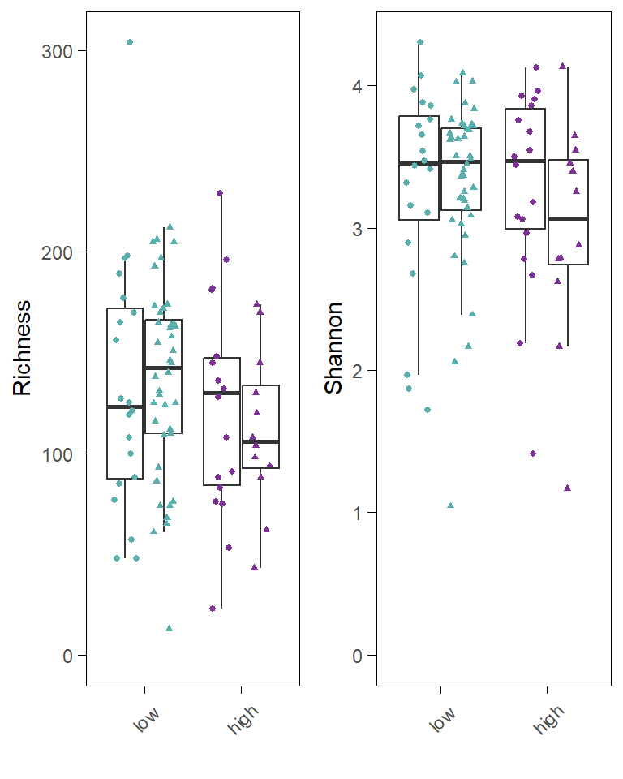

```r
alpha_div_plots[[paste(segment,"Country")]]
```

#### 2.6.0.2 Beta diversity

**Main results**

```r
pairwise_aitchison_raw[[paste("genus", segment)]]
```

```
                  pairs Df SumsOfSqs   F.Model         R2 p.value p.adjusted
1           low vs high  1  186.5579 1.0457378 0.01150575   0.320      0.320
2 low vs high , Country  1  473.1877 2.6524217 0.02918333   0.001      0.001
3 low vs high : Country  1  171.1419 0.9588709 0.01055499   0.567      0.567
  sig
1
2 ***
3
```

*PCA*

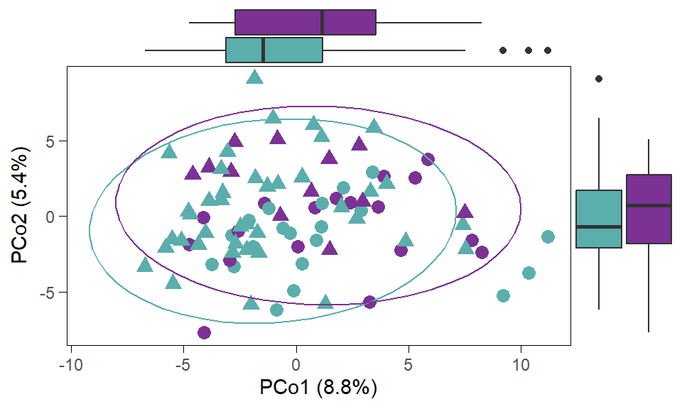

```r
pca_plots_list[[paste(segment,"genus custom")]]
```

#### 2.6.0.3 Univariate analysis

**Number of significant taxa**

```r
knitr::kable(as.data.frame(lapply(list_intersections,nrow)) %>% t() %>%
  `colnames<-`("Count") %>%
  `rownames<-`(c(names(list_intersections))),caption="Number of significant taxa")
```

Number of significant taxa

|  | Count |
| --- | --- |
| terminal_ileum genus low vs high | 0 |

#### 2.6.0.4 Machine learning

**Main models**

```r
knitr::kable(models_summ_df_ileum %>% dplyr::select(
"alpha","lambda",
"auc_optimism_corrected",
"auc_optimism_corrected_CIL",
"auc_optimism_corrected_CIU"),
             digits=2,caption="Elastic net results")
```

Elastic net results

|  | alpha | lambda | auc_optimism_corrected | auc_optimism_corrected_CIL | auc_optimism_corrected_CIU |
| --- | --- | --- | --- | --- | --- |
| low vs high ASV terminal_ileum | 0 | 9.33 | 0.63 | 0.40 | 0.79 |
| low vs high genus terminal_ileum | 0 | 0.15 | 0.62 | 0.55 | 0.69 |

**ROC - Genus level**

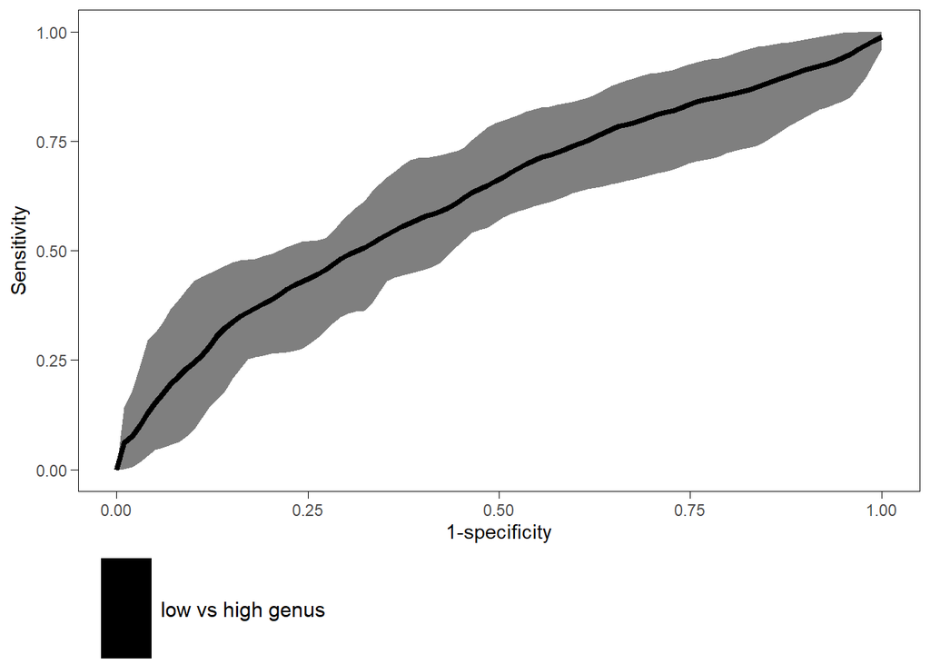

```r
p <- roc_curve_all_custom(roc_cs[2],Q="Q5",
                     model_name="enet_model")

p
```

# 3 Data Analysis - Colon

```r
segment="colon"
```

## 3.1 Filtering

Rules:

- sequencing depth > 10000
- nearZeroVar() with default settings

**Rarefaction Curve**

```r
path="../../../intermediate_files/rarecurves"
seq_depth_threshold <- 10000
```

```r
ps <- construct_phyloseq(colon_asv_tab,colon_taxa_tab,colon_metadata)
rareres <- get_rarecurve(obj=ps, chunks=500)
save(rareres,file = file.path(path,"rarefaction_colon.Rdata"))
```

```r
load(file.path(path,"rarefaction_colon.Rdata"))

prare <- ggrarecurve(obj=rareres,
                      factorNames="Country",
                      indexNames=c("Observe")) +
  theme_bw() +
  theme(axis.text=element_text(size=8), panel.grid=element_blank(),
        strip.background = element_rect(colour=NA,fill="grey"),
        strip.text.x = element_text(face="bold")) +
  geom_vline(xintercept = seq_depth_threshold,
             linetype="dashed",
             color = "red") +
  xlim(0, 20000)
```

```
The color has been set automatically, you can reset it manually by adding scale_color_manual(values=yourcolors)
```

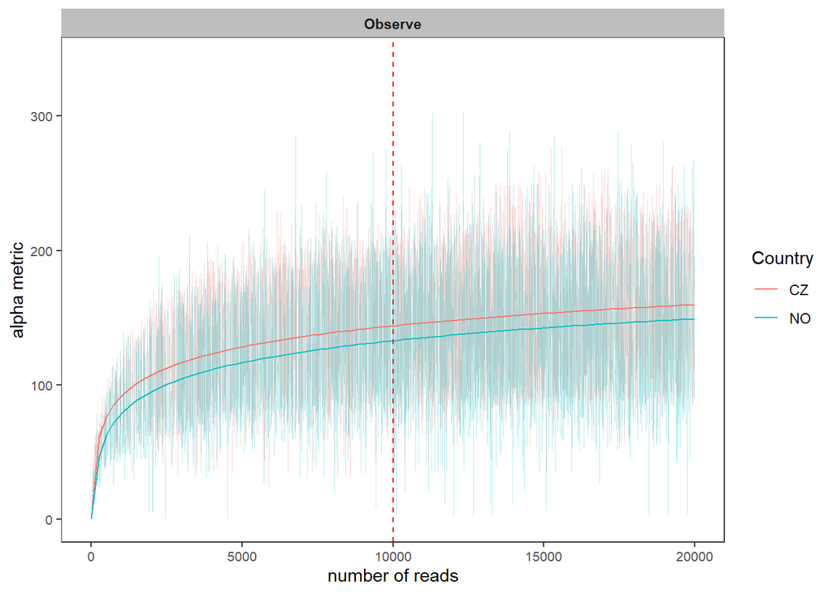

```r
prare
```

**Library size**

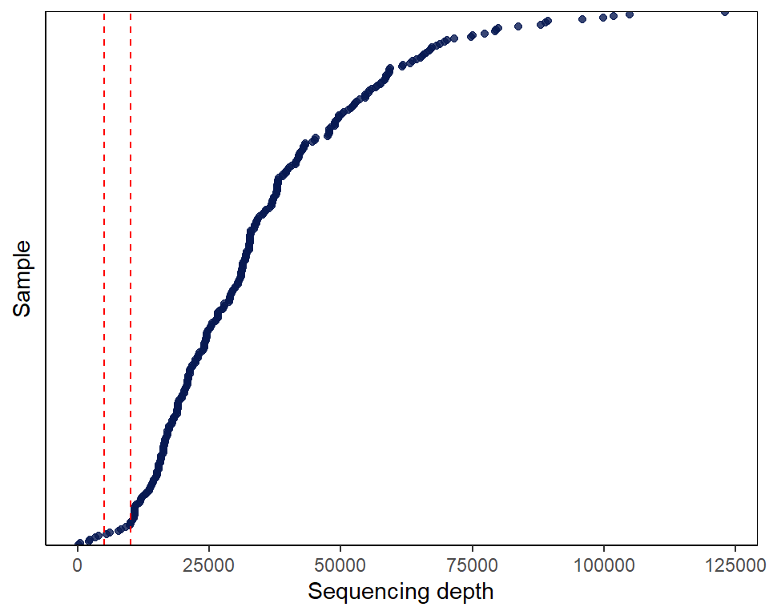

```r
read_counts(colon_asv_tab, line = c(5000,10000))
```

### 3.1.1 Sequencing depth

```r
data_filt <- seq_depth_filtering(colon_asv_tab,
                                 colon_taxa_tab,
                                 colon_metadata,
                                 seq_depth_threshold = 10000)
```

```
Removing 308 ASV(s)
```

```r
filt_colon_asv_tab <- data_filt[[1]]; alpha_colon_asv_tab <- filt_colon_asv_tab
filt_colon_taxa_tab <- data_filt[[2]]; alpha_colon_taxa_tab <- filt_colon_taxa_tab
filt_colon_metadata <- data_filt[[3]]; alpha_colon_metadata <- filt_colon_metadata

seq_step <- dim(filt_colon_asv_tab)[1]
```

**Library size**

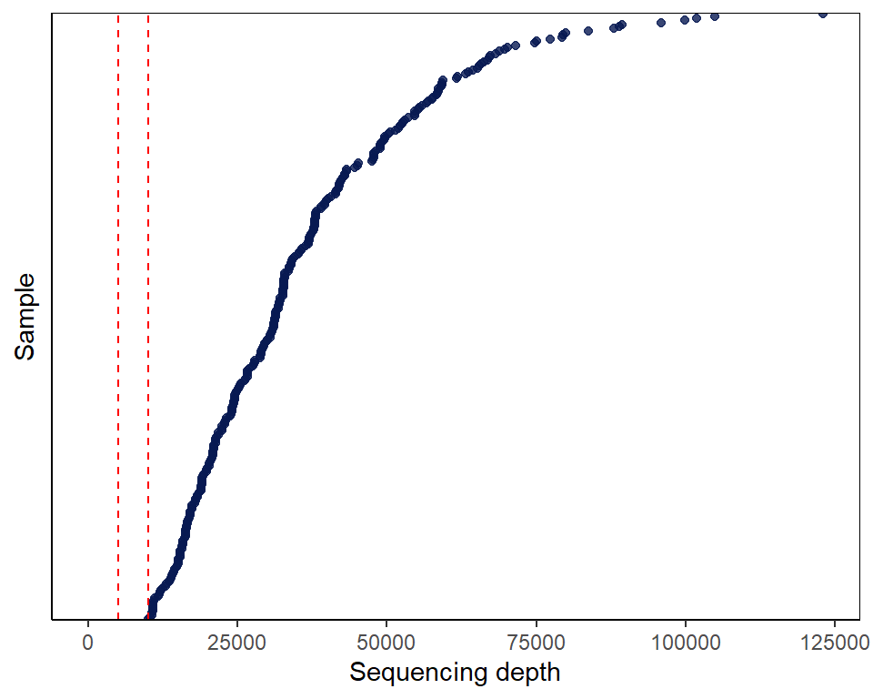

```r
read_counts(filt_colon_asv_tab,line = c(5000,10000))
```

### 3.1.2 NearZeroVar

```r
data_filt <- nearzerovar_filtering(filt_colon_asv_tab,
                                   filt_colon_taxa_tab,
                                   filt_colon_metadata)

filt_colon_asv_tab <- data_filt[[1]]
filt_colon_taxa_tab <- data_filt[[2]]
nearzero_step <- dim(filt_colon_asv_tab)[1]
```

Library size

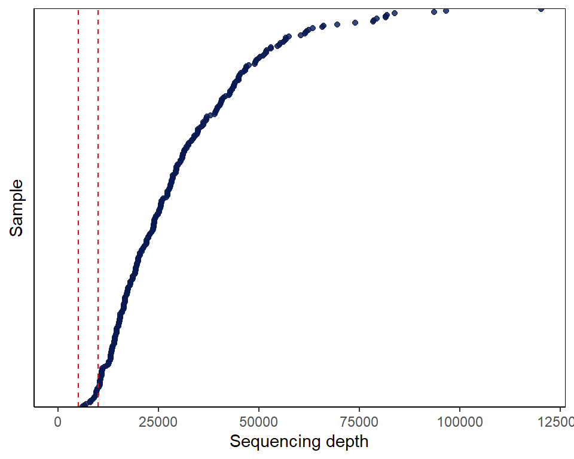

```r
read_counts(filt_colon_asv_tab,line = c(5000,10000))
```

### 3.1.3 Final Counts

```r
final_counts_filtering(colon_asv_tab,
                       filt_colon_asv_tab,
                       filt_colon_metadata,
                       seq_step, 0, nearzero_step) %>% `colnames<-`("Count")
```

```
                                            Count
Raw data: ASVs                               4084
Raw data: Samples                             306
Sequencing depth filt: ASVs                  3776
Prevalence filt: ASVs                           0
NearZeroVar filt: ASVs                        342
Filt data: ASVs                               342
Filt data: Samples                            293
Filt data: Patients                           121
Filt data: Patients.1                           0
Filtered samples                               13
Matrices                    Cecum;Rectum;CD;CA;SI
healthy                                         0
non-rPSC                                        0
rPSC                                           73
pre_ltx                                       220
post_ltx                                        0
ETOH                                            0
```

## 3.2 Alpha diversity

```r
path = "../../../results/merged_sites/main_analysis/Q5/alpha_diversity"
```

**Calculation**

```r
# Construct MPSE object
alpha_colon_metadata$Sample <- alpha_colon_metadata$SampleID
colon_mpse <- as.MPSE(construct_phyloseq(alpha_colon_asv_tab,
                                         alpha_colon_taxa_tab,
                                         alpha_colon_metadata))

colon_mpse %<>% mp_rrarefy(raresize = 10000,seed = 123)

# Calculate alpha diversity - rarefied counts
colon_mpse %<>% mp_cal_alpha(.abundance=RareAbundance, force=TRUE)
```

```r
# preparing data frame
alpha_data <- data.frame(SampleID=colon_mpse$Sample.x,
                         Observe=colon_mpse$Observe,
                         Shannon=colon_mpse$Shannon,
                         Simpson=colon_mpse$Simpson,
                         Pielou=colon_mpse$Pielou,
                         Group=colon_mpse$Calprotectin_groups,
                         Country=colon_mpse$Country,
                         Patient=colon_mpse$Patient)

write.csv(alpha_data,file.path(path,paste0("alpha_indices_",segment,".csv")),
          row.names = FALSE)

alpha_data %<>% drop_na()
```

### 3.2.1 Plots

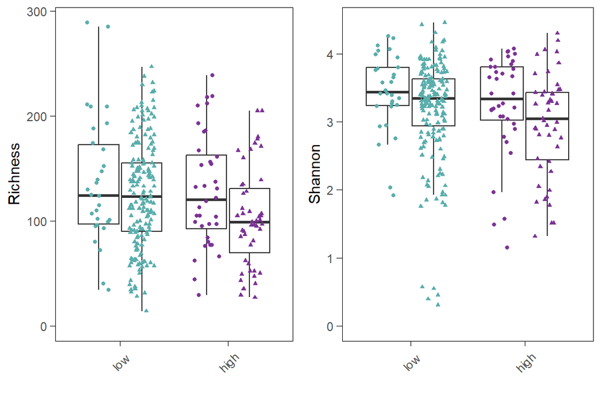

```r
p_boxplot_alpha <- alpha_diversity_countries(alpha_data,
                                             show_legend = FALSE,
                                             size=1,gap=FALSE)
# save the results
alpha_div_plots[[paste(segment,"Country")]] <- p_boxplot_alpha

# see the results
p_boxplot_alpha
```

### 3.2.2 Linear Model

```r
path = "../../../results/merged_sites/main_analysis/Q5/alpha_diversity"
alpha_data <- read.csv(file.path(path,paste0("alpha_indices_",segment,".csv")))
```

**Richness**

```r
results_model <- pairwise.lmer(formula = "Observe ~ Group * Country +  (1|Patient)",
                             factors=alpha_data$Group,
                             data=alpha_data)

# check interaction
if (!is.data.frame(results_model)){
  results_model_observe <- results_model[[1]]
  results_model_observe_emeans <- results_model[[2]]
} else {
  results_model_observe <- results_model
  results_model_observe_emeans <- NA
}

# save the results
pc_observed[[segment]] <- results_model_observe
```

```r
# see the results
knitr::kable(results_model_observe,digits = 3,
caption = "Raw results of linear model of richness estimation.")
```

Raw results of linear model of richness estimation.

|  | Estimate | Std..Error | df | t.value | Pr…t.. | p.adj | sig |
| --- | --- | --- | --- | --- | --- | --- | --- |
| low vs Grouphigh | -10.382 | 17.179 | 118.864 | -0.604 | 0.547 | 0.547 |  |
| low vs high - CZ vs NO | -14.423 | 13.672 | 119.220 | -1.055 | 0.294 | 0.294 |  |
| low vs Grouphigh:CountryNO | -10.672 | 22.099 | 117.864 | -0.483 | 0.630 | 0.630 |  |

```r
knitr::kable(results_model_observe_emeans,digits = 3,
caption = "Raw results of independent country analysis")
```

Table: Raw results of independent country analysis

**Shannon**

```r
results_model <- pairwise.lmer(formula = "Shannon ~ Group * Country + (1|Patient)",
                             factors=alpha_data$Group,
                             data=alpha_data)

# check interaction
if (!is.data.frame(results_model)){
  results_model_shannon <- results_model[[1]]
  results_model_shannon_emeans <- results_model[[2]]
} else {
  results_model_shannon <- results_model
  results_model_shannon_emeans <- NA
}

# save the results
pc_shannon[[segment]] <- as.data.frame(results_model_shannon)
```

```r
# see the results
knitr::kable(results_model_shannon,digits = 3,
caption = "Raw results of linear model of Shannon estimation.")
```

Raw results of linear model of Shannon estimation.

|  | Estimate | Std..Error | df | t.value | Pr…t.. | p.adj | sig |
| --- | --- | --- | --- | --- | --- | --- | --- |
| low vs Grouphigh | -0.203 | 0.238 | 119.622 | -0.853 | 0.395 | 0.395 |  |
| low vs high - CZ vs NO | -0.259 | 0.190 | 120.062 | -1.363 | 0.175 | 0.175 |  |
| low vs Grouphigh:CountryNO | -0.005 | 0.307 | 118.364 | -0.015 | 0.988 | 0.988 |  |

```r
knitr::kable(results_model_shannon_emeans,digits = 3,
caption = "Raw results of independent country analysis")
```

Table: Raw results of independent country analysis

**Simpson**

```r
results_model <- pairwise.lmer(formula = "Simpson ~ Group * Country + (1|Patient)",
                                     factors=alpha_data$Group,
                                     data=alpha_data)

# check interaction
if (!is.data.frame(results_model)){
  results_model_simpson <- results_model[[1]]
  results_model_simpson_emeans <- results_model[[2]]
} else {
  results_model_simpson <- results_model
  results_model_simpson_emeans <- NA
}


# save the results
pc_simpson[[segment]] <- as.data.frame(results_model_simpson)
```

```r
# see the results
knitr::kable(results_model_simpson,digits = 3,
caption = "Raw results of linear model of Simpson estimation.")
```

Raw results of linear model of Simpson estimation.

|  | Estimate | Std..Error | df | t.value | Pr…t.. | p.adj | sig |
| --- | --- | --- | --- | --- | --- | --- | --- |
| low vs Grouphigh | -0.035 | 0.040 | 119.722 | -0.888 | 0.376 | 0.376 |  |
| low vs high - CZ vs NO | -0.038 | 0.032 | 120.159 | -1.206 | 0.230 | 0.230 |  |
| low vs Grouphigh:CountryNO | 0.023 | 0.051 | 118.473 | 0.455 | 0.650 | 0.650 |  |

```r
knitr::kable(results_model_simpson_emeans,digits = 3,
caption = "Raw results of independent country analysis")
```

Table: Raw results of independent country analysis

### 3.2.3 Saving results

```r
alpha_list <- list(
  Richness=pc_observed[[segment]],
  Shannon=pc_shannon[[segment]])

write.xlsx(alpha_list,
           file = file.path(path,paste0("alpha_diversity_results_",segment,".xlsx")))
```

## 3.3 Beta diversity

### 3.3.1 Main analysis

**Genus level, Aitchison distance**

```r
level="genus"
```

```r
path = "../../../results/merged_sites/main_analysis/Q5/beta_diversity"
```

Aggregation, filtering

```r
# Aggregation
genus_data <- aggregate_taxa(colon_asv_tab,
                             colon_taxa_tab,
                             taxonomic_level=level,
                             names=TRUE)
# Filtration
filt_data <- filtering_steps(genus_data[[1]],
                             genus_data[[2]],
                             colon_metadata,
                             seq_depth_threshold=10000)
```

```
Removing 32 ASV(s)
```

```r
filt_colon_genus_tab <- filt_data[[1]]
filt_colon_genus_taxa <- filt_data[[2]]
filt_colon_metadata <- filt_data[[3]]

filt_colon_metadata %<>% dplyr::mutate(Group=Calprotectin_groups)
```

##### 3.3.1.0.1 PERMANOVA

```r
pairwise_df <- filt_colon_genus_tab %>% column_to_rownames("SeqID") %>% t()

# main effect
pp_main <- pairwise.adonis(pairwise_df,filt_colon_metadata$Group,
                           covariate = filt_colon_metadata$Country,
                           patients = filt_colon_metadata$Patient,
                           sim.method = "robust.aitchison", p.adjust.m="BH")

# interaction
pp_int <- pairwise.adonis(pairwise_df,filt_colon_metadata$Group,
                          covariate = filt_colon_metadata$Country,
                          interaction = TRUE,
                          patients = filt_colon_metadata$Patient,
                          sim.method = "robust.aitchison", p.adjust.m="BH")

# tidy the results
pp_factor <- pp_main[[1]]
pp_cov <- pp_main[[2]]
pp_fac.cov <- pp_int[[3]]

cols <- c("pairs","Df","SumsOfSqs", "F.Model","R2","p.value", "p.adjusted", "sig")
colnames(pp_factor) <- cols; colnames(pp_cov) <- cols; colnames(pp_fac.cov) <- cols;

# save raw results
pairwise_aitchison_raw[[paste(level, segment)]] <-rbind(pp_factor,pp_cov,pp_fac.cov)
```

```r
# see the results
knitr::kable(pp_factor,digits = 3,caption = "PERMANOVA, GROUP separation")
```

PERMANOVA, GROUP separation

| pairs | Df | SumsOfSqs | F.Model | R2 | p.value | p.adjusted | sig |
| --- | --- | --- | --- | --- | --- | --- | --- |
| low vs high | 1 | 318.485 | 2.059 | 0.007 | 0.857 | 0.857 |  |

```r
knitr::kable(pp_cov,digits = 3,caption = "PERMANOVA, COUNTRY separation")
```

PERMANOVA, COUNTRY separation

| pairs | Df | SumsOfSqs | F.Model | R2 | p.value | p.adjusted | sig |
| --- | --- | --- | --- | --- | --- | --- | --- |
| low vs high , Country | 1 | 661.475 | 4.277 | 0.014 | 0.003 | 0.003 | ** |

```r
knitr::kable(pp_fac.cov,digits = 3,caption = "PERMANOVA, INTERACTION GROUP:Country")
```

PERMANOVA, INTERACTION GROUP:Country

| pairs | Df | SumsOfSqs | F.Model | R2 | p.value | p.adjusted | sig |
| --- | --- | --- | --- | --- | --- | --- | --- |
| low vs high : Country | 1 | 246.488 | 1.597 | 0.005 | 0.955 | 0.955 |  |

Interaction check

```r
interaction_sig <- pp_fac.cov$pairs[pp_fac.cov$p.adjusted < 0.1]

if (length(interaction_sig)>0){
 for (i in 1:length(interaction_sig)){
  group1 <- unlist(strsplit(interaction_sig[i],split = " vs "))[1]
  group2 <- unlist(strsplit(interaction_sig[i],split = " vs "))[2]
  group2 <- unlist(strsplit(group2,split = " : "))[1]

  result_list <- adonis_postanalysis(x=pairwise_df,
                      factors = filt_colon_genus_metadata$Group,
                      covariate = filt_colon_genus_metadata$Country,
                      group1 = group1,
                      group2 = group2,
                      patients = filt_colon_genus_metadata$Patient)
  print(result_list)
}
}
```

##### 3.3.1.0.2 Plots

**PCoA custom**

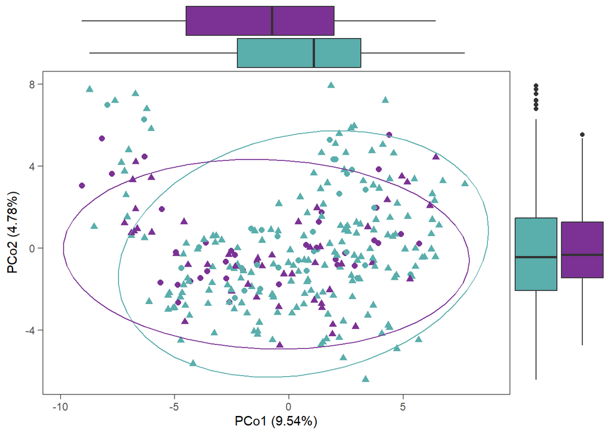

```r
p <- pca_plot_custom(filt_colon_genus_tab,
                                 filt_colon_genus_taxa,
                                 filt_colon_metadata,
                                 show_boxplots = TRUE,
                                 variable = "Group", size=2,
                                 show_legend=FALSE)

# save the results
pca_plots_list[[paste(segment,level,"custom")]] <- p

# see the results
p
```

#### 3.3.1.1 Saving results

```r
write.xlsx(pairwise_aitchison_raw[[paste(level, segment)]],
           file = file.path(path,
           paste0("beta_diversity_results_", segment,".xlsx")))
```

## 3.4 Univariate Analysis

### 3.4.1 Main - Genus level

```r
level="genus"
```

```r
# needed paths
path = "../../../results/merged_sites/main_analysis/Q5/univariate_analysis"
path_maaslin=file.path("../../../intermediate_files/maaslin/Q5",level)
```

```r
# variables
raw_linda_results_genus[[segment]] <- list()
linda_results_genus[[segment]] <- list()

# country and interaction problems
list_intersections <- list()
list_venns <- list()
uni_statistics <- list()

# workbook for final df
wb <- createWorkbook()
```

#### 3.4.1.1 Genus level

```r
level="genus"
```

Aggregate taxa

```r
genus_data <- aggregate_taxa(colon_asv_tab,
                             colon_taxa_tab,
                             taxonomic_level = level)

colon_genus_tab <- genus_data[[1]]
colon_genus_taxa_tab <- genus_data[[2]]

colon_genus_asv_taxa_tab <- create_asv_taxa_table(colon_genus_tab,
                                                  colon_genus_taxa_tab)
```

##### 3.4.1.1.1 low vs high

```r
group <- c("low","high")
comparison_name <- paste0(group[1], " vs ",group[2])
```

###### 3.4.1.1.1.1 linda

```r
colon_metadata %<>% dplyr::mutate(Group=Calprotectin_groups)

# prepare the data
linda_data <- binomial_prep(colon_genus_tab,
                            colon_genus_taxa_tab,
                            colon_metadata,
                            group, usage="linDA")
```

```
Removing 25 ASV(s)
```

```
Removing 7 ASV(s)
```

```r
filt_colon_uni_data <- linda_data[[1]]
filt_colon_uni_taxa <- linda_data[[2]]
filt_colon_uni_metadata <- linda_data[[3]]

# fit the model
linda.obj <- linda(filt_colon_uni_data,
                   filt_colon_uni_metadata,
                   formula = '~ Group * Country + (1|Patient)')
```

```
0  features are filtered!
The filtered data has  293  samples and  164  features will be tested!
Imputation approach is used.
Fit linear mixed effects models ...
Completed.
```

```r
linda.output <- linda.obj$output
linda.output <- linda_renaming(linda.output, group)

# save the results
group1 <- paste0(group[1], " vs ","Group",group[2])
group2 <- paste0(group[1], " , ",group[2], " - CZ vs NO")
group3 <- paste0(group[1], " vs ","Group",group[2], ":CountryNO")


for (grp in c(group1,group2,group3)){
  raw_linda_results_genus[[segment]][[grp]] <-
    rawlinda.df(linda.output,
                grp,
                filt_colon_uni_data,
                filt_colon_uni_taxa)

  linda_results_genus[[segment]][[grp]] <-
    linda.df(linda.output,
             grp,
             filt_colon_uni_data,
             filt_colon_uni_taxa)
}
```

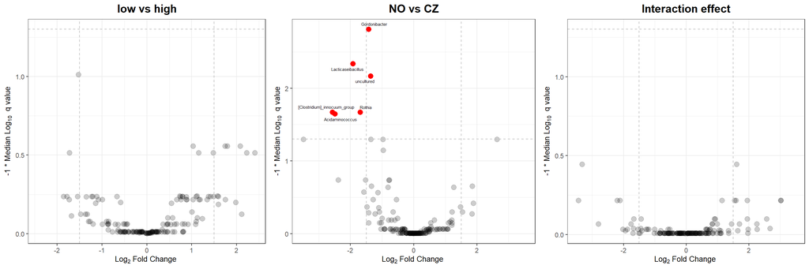

```r
# volcano plot
volcano_1 <- volcano_plot_linda(linda.output, group1,
                                taxa_table = filt_colon_uni_taxa) +
            ggtitle(paste(group,collapse=" vs "))

volcano_2  <- volcano_plot_linda(linda.output, group2,
                                taxa_table = filt_colon_uni_taxa) +
            ggtitle("NO vs CZ")

volcano_3 <- volcano_plot_linda(linda.output, group3,
                                taxa_table = filt_colon_uni_taxa) +
            ggtitle("Interaction effect")

volcano <- ggarrange(volcano_1,volcano_2,volcano_3, ncol=3)

# see the plot
volcano
```

###### 3.4.1.1.1.2 MaAsLin2

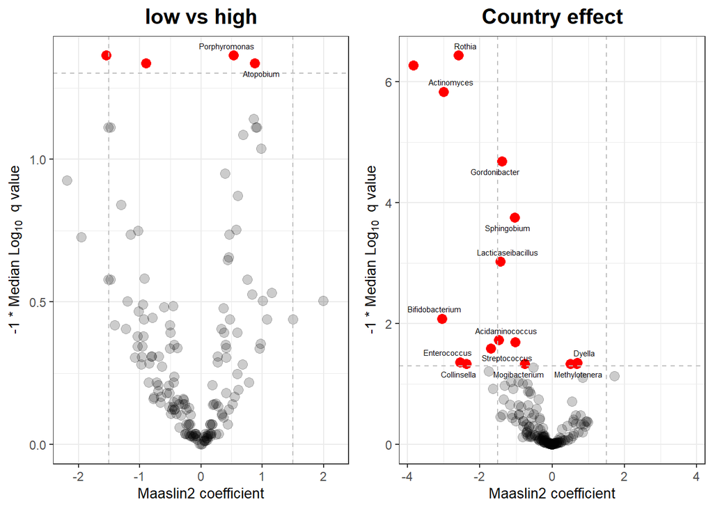

```r
volcano1 <- volcano_plot_maaslin(fit_data,filt_colon_uni_taxa) +
            ggtitle(paste(group[1], "vs", group[2]))

volcano2 <- volcano_plot_maaslin(fit_data,filt_colon_uni_taxa,variable="Country") +
            ggtitle("Country effect")

volcano <- ggarrange(volcano1,volcano2, ncol=2)
volcano
```

###### 3.4.1.1.1.3 Group - Intersection

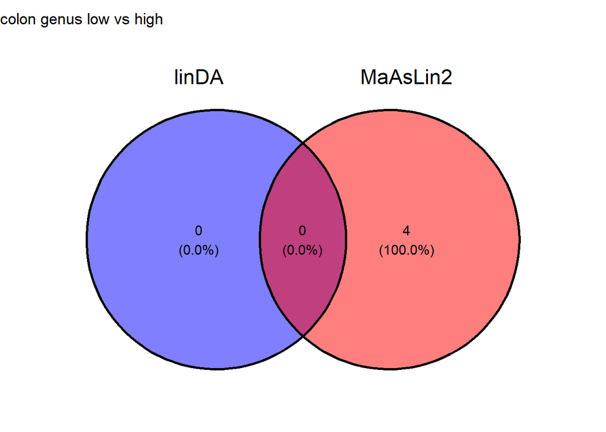

```r
intersection_results <- group_intersection(group, list_intersections, list_venns,
                                           linda.output, fit_data,
                                           raw_linda_results_genus,
                                           segment = segment,
                                           level=level)

list_intersections <- intersection_results[[1]]
list_venns <- intersection_results[[2]]
venn <- intersection_results[[3]]

# show the results
venn
```

###### 3.4.1.1.1.4 Interaction effect

```r
list_interaction_significant <- country_interaction(group,
                                                    linda.output,
                                                    list_intersections,
                                          filt_colon_uni_data,
                                          filt_colon_uni_metadata,
                                          segment=segment,
                                          level=level)

# see the result
## significant interaction effect
list_interaction_significant[[1]]
```

```r
## results for czech cohort
list_interaction_significant[[2]]
```

```
[1] NA
```

```r
## results for norwegian cohort
list_interaction_significant[[3]]
```

```
[1] NA
```

Removing problematic taxa

```r
list_intersections <- removing_interaction_problems(group,
                                                    list_interaction_significant,
                                                    list_intersections,
                                                    segment=segment,
                                                    level=level)
```

##### 3.4.1.1.2 Basic statistics

```r
uni_df <-  merge(basic_univariate_statistics(linda_data,group),
                 raw_linda_results_genus[[segment]][[group1]],
                 by="SeqID",all=TRUE)
```

```
[1] "low"
[1] "high"
[1] "low"
[1] "high"
```

```r
uni_df[["final_sig"]] <- uni_df$SeqID %in% list_intersections[[paste(segment,level,comparison_name)]][["SeqID"]]
uni_statistics[[segment]][[paste(level,comparison_name)]] <- uni_df

# for comparison
new_name <- comparison_name
addWorksheet(wb, sheetName = new_name)
writeData(wb, sheet = new_name, uni_df, rowNames=FALSE)
```

##### 3.4.1.1.3 Visualization

Heatmap visualizing the linDA’s logFoldChange for taxa with p < 0.1.

```r
list_heatmap <- list_intersections[grep(paste(segment,level),
                                  names(list_intersections),value=TRUE)]
if (length((list_heatmap[[1]][[1]]))>1){
p_heatmap_linda <- heatmap_linda(list_heatmap,colon_taxa_tab)
p_heatmap_linda
}
```

Dot heatmap

```r
if (length((list_heatmap[[1]][[1]]))>0){
dotheatmap_linda <- dot_heatmap_linda(list_heatmap,
                                      uni_statistics$terminal_ileum[grepl(level,names(uni_statistics$terminal_ileum))],
                                      colon_taxa_tab)
dotheatmap_linda
}
```

**Horizontal bar plot**

```r
if (length((list_heatmap[[1]][[1]]))>0){
p_prevalence <- horizontal_barplot(wb,taxa=levels(dotheatmap_linda$data$SeqID))

p_prevalence_final <- ggarrange(p_prevalence,
                                ggplot() + theme_minimal(),
                                nrow = 2,heights = c(1,0.085))
p <- ggarrange(dotheatmap_linda + theme(legend.position = "none"),p_prevalence_final,ncol=2,widths = c(1,0.2))
p
}
```

#### 3.4.1.2 Saving results

```r
# ALL DATA
saveWorkbook(wb,file.path(path,paste0("uni_analysis_wb_",segment,".xlsx")),
             overwrite = TRUE)

# SIGNIFICANT taxa

write.xlsx(list_intersections[grepl(segment,names(list_intersections))] %>%
            `names<-`(gsub(segment, "", names(
              list_intersections[grepl(segment,names(list_intersections))]))),
           file.path(path,paste0("significant_taxa_",segment,".xlsx")))
```

## 3.5 Machine learning

```r
path = "../../../results/merged_sites/main_analysis/Q5/models"
```

### 3.5.1 ElasticNet

```r
model="enet"
```

#### 3.5.1.1 ASV level

```r
level="ASV"
```

```r
group <- c("low","high")
comparison_name <- paste0(group[1], " vs ",group[2])
```

```r
model_name <- paste(comparison_name,level,segment)

# prepare the data
filt_colon_uni_data <- binomial_prep(colon_asv_tab,
                                     colon_taxa_tab,
                                     colon_metadata,
                                     group, usage="ml_clr",patient = TRUE)
```

```
Removing 264 ASV(s)
```

```
Removing 44 ASV(s)
```

```r
# fit the model
enet_model <- glmnet_binomial(filt_colon_uni_data,
                              sample_method = "atypboot",
                              outcome="Group",
                              N=10,
                              reuse=TRUE,
                              file=model_name,clust_var = "Patient",
                              Q="Q5")

# ROC curve
roc_c <- roc_curve(enet_model, group)

# save the results
models_summ <- list()
models_cm <- list()
betas <- list()
roc_cs <- list()

models_summ[[model_name]] <- enet_model$model_summary
models_cm[[model_name]] <- enet_model$conf_matrices$original
roc_cs[[model_name]] <- enet_model$kfold_rocobjs
betas[[model_name]] <- as.matrix(enet_model$betas)

# see the results
enet_model$model_summary %>% t()
```

```
                                       [,1]
alpha                           1.000000000
lambda                          0.002352995
auc                             1.000000000
auc_czech                       1.000000000
auc_no                          1.000000000
auc_optimism_corrected          0.576388400
auc_optimism_corrected_CIL      0.418467650
auc_optimism_corrected_CIU      0.690289785
accuracy                        1.000000000
accuracy_czech                          NaN
accuracy_no                     1.000000000
accuracy_optimism_corrected     0.640802202
accuracy_optimism_corrected_CIL 0.528153409
accuracy_optimism_corrected_CIU 0.733313084
```

```r
enet_model$conf_matrices
```

```
$original
    Predicted
True   0   1
   0  83   0
   1   0 210

$czech
    Predicted
True  0  1
   0 36  0
   1  0 30

$no
    Predicted
True   0   1
   0  47   0
   1   0 180
```

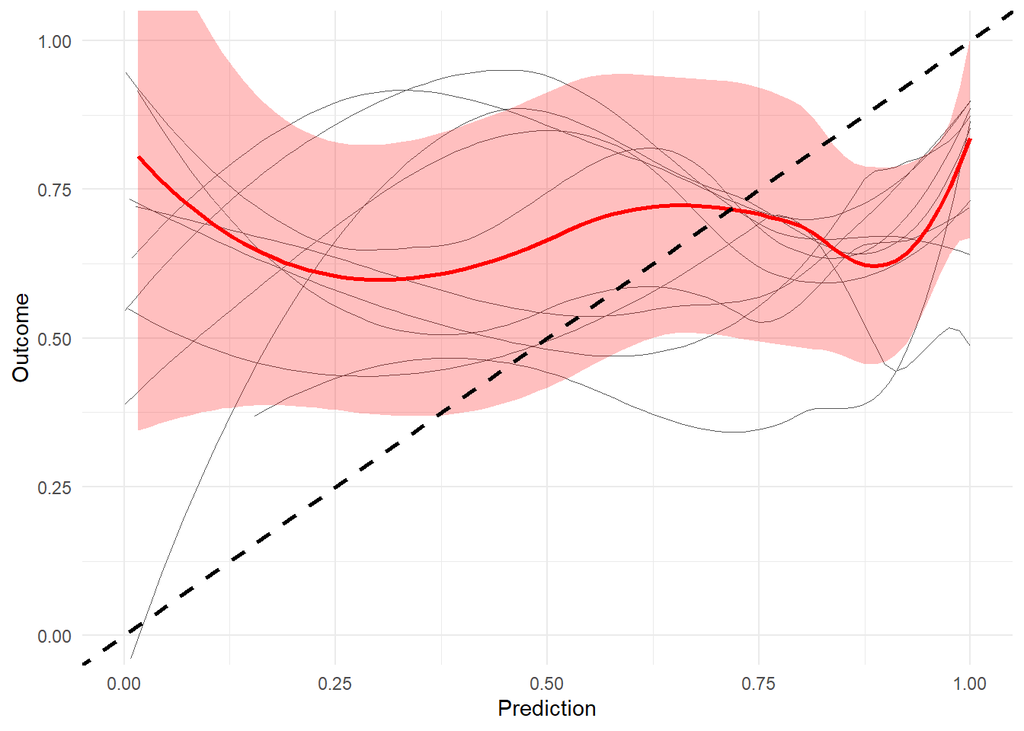

```r
enet_model$plot
```

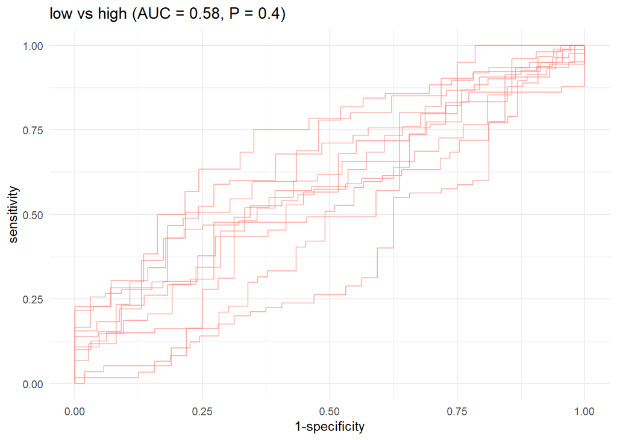

```r
roc_c
```

#### 3.5.1.2 Genus level

```r
level="genus"
```

Aggregate taxa

```r
genus_data <- aggregate_taxa(colon_asv_tab,
                             colon_taxa_tab,
                             taxonomic_level = level)

colon_genus_tab <- genus_data[[1]]
colon_genus_taxa_tab <- genus_data[[2]]
```

##### 3.5.1.2.1 low vs high

```r
group <- c("low","high")
comparison_name <- paste0(group[1], " vs ",group[2])
```

```r
model_name <- paste(comparison_name,level,segment)

# prepare the data
filt_colon_uni_data <- binomial_prep(colon_genus_tab,
                                     colon_genus_taxa_tab,
                                     colon_metadata,
                                     group,
                                     usage="ml_clr",patient = TRUE)
```

```
Removing 25 ASV(s)
```

```
Removing 7 ASV(s)
```

```r
# fit the model
enet_model <- glmnet_binomial(filt_colon_uni_data,
                              sample_method = "atypboot",
                              outcome="Group",
                              N=10,
                              reuse=TRUE,clust_var = "Patient",
                              file=model_name,
                              Q="Q5")

# ROC
roc_c <- roc_curve(enet_model, group)

# save the results
models_summ[[model_name]] <- enet_model$model_summary
models_cm[[model_name]] <- enet_model$conf_matrices$original
roc_cs[[model_name]] <- enet_model$kfold_rocobjs
betas[[model_name]] <- as.matrix(enet_model$betas)

# see the results
enet_model$model_summary %>% t()
```

```
                                      [,1]
alpha                           0.20000000
lambda                          0.01770854
auc                             1.00000000
auc_czech                       1.00000000
auc_no                          1.00000000
auc_optimism_corrected          0.61887455
auc_optimism_corrected_CIL      0.50314091
auc_optimism_corrected_CIU      0.73986549
accuracy                        0.99658703
accuracy_czech                         NaN
accuracy_no                     0.99559471
accuracy_optimism_corrected     0.66245735
accuracy_optimism_corrected_CIL 0.55821114
accuracy_optimism_corrected_CIU 0.72898906
```

```r
enet_model$conf_matrices
```

```
$original
    Predicted
True   0   1
   0  82   1
   1   0 210

$czech
    Predicted
True  0  1
   0 36  0
   1  0 30

$no
    Predicted
True   0   1
   0  46   1
   1   0 180
```

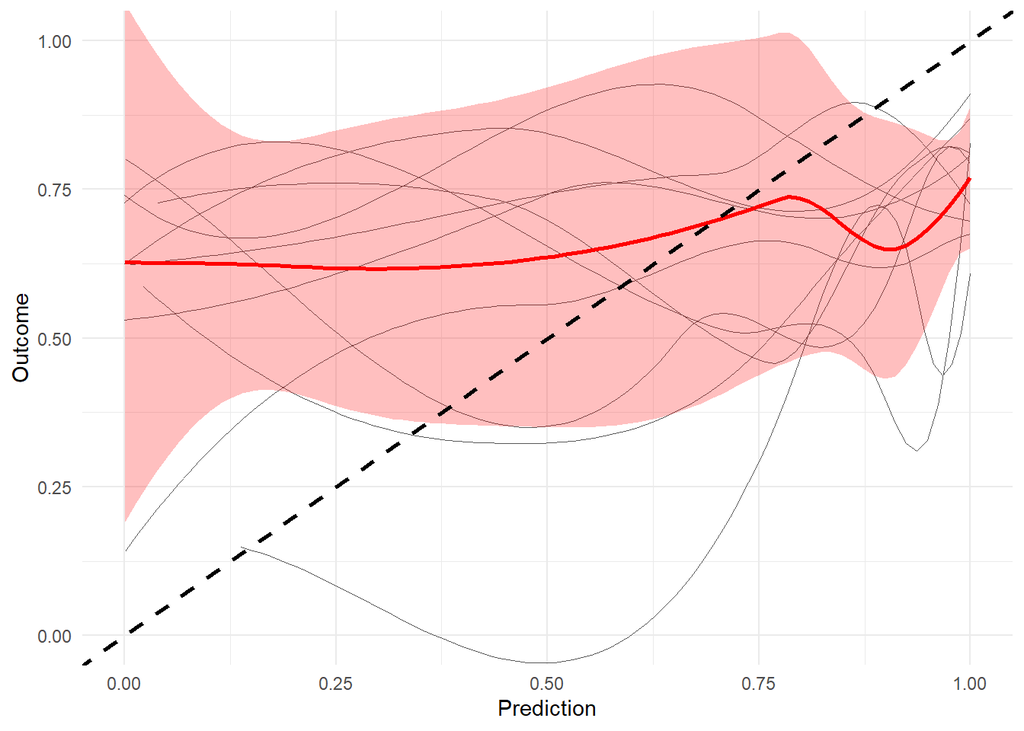

```r
enet_model$plot
```

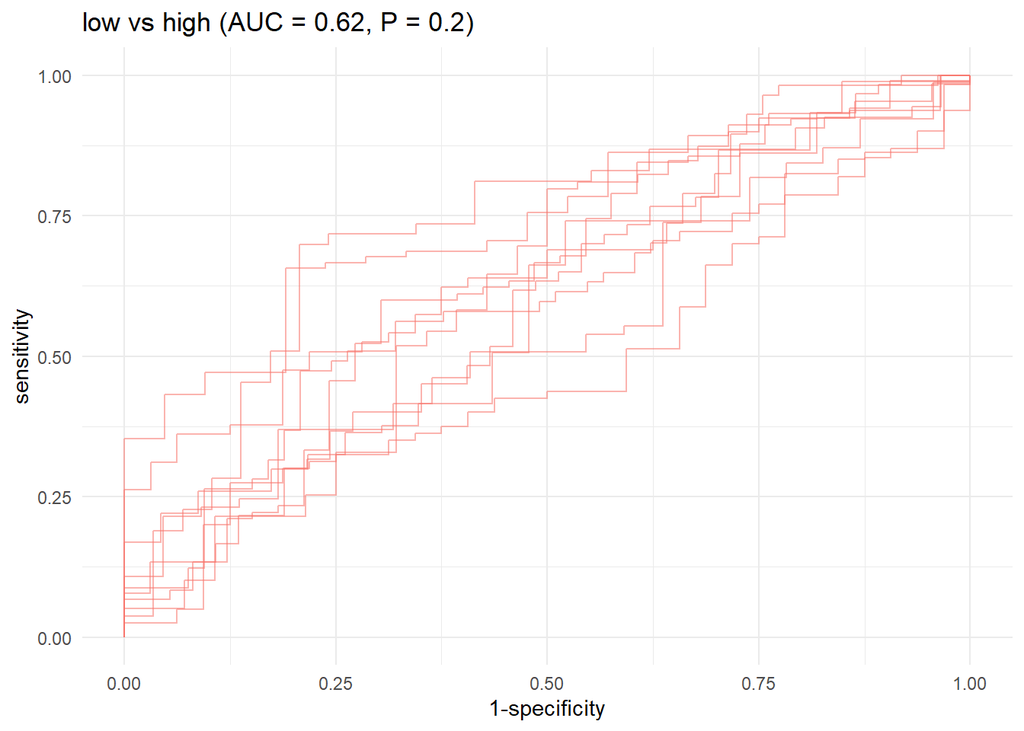

```r
roc_c
```

#### 3.5.1.3 Saving results

```r
models_summ_df_colon <- do.call(rbind,
  models_summ[grep(segment,names(models_summ),value = TRUE)])

write.csv(models_summ_df_colon,file.path(path,paste0("elastic_net_",segment,".csv")))
```

## 3.6 Results overview

#### 3.6.0.1 Alpha diversity

```r
pc_observed[[segment]]
```

```
                            Estimate Std..Error       df    t.value  Pr...t..
low vs Grouphigh           -10.38203   17.17915 118.8636 -0.6043391 0.5467700
low vs high - CZ vs NO     -14.42260   13.67170 119.2200 -1.0549238 0.2935933
low vs Grouphigh:CountryNO -10.67238   22.09860 117.8642 -0.4829439 0.6300314
                               p.adj sig
low vs Grouphigh           0.5467700
low vs high - CZ vs NO     0.2935933
low vs Grouphigh:CountryNO 0.6300314
```

```r
pc_shannon[[segment]]
```

```
                               Estimate Std..Error       df     t.value
low vs Grouphigh           -0.203414982  0.2384651 119.6223 -0.85301770
low vs high - CZ vs NO     -0.258723672  0.1898142 120.0617 -1.36303680
low vs Grouphigh:CountryNO -0.004629771  0.3065856 118.3638 -0.01510107
                            Pr...t..     p.adj sig
low vs Grouphigh           0.3953543 0.3953543
low vs high - CZ vs NO     0.1754218 0.1754218
low vs Grouphigh:CountryNO 0.9879770 0.9879770
```

```r
pc_simpson[[segment]]
```

```
                              Estimate Std..Error       df    t.value  Pr...t..
low vs Grouphigh           -0.03519075 0.03962315 119.7223 -0.8881361 0.3762484
low vs high - CZ vs NO     -0.03804238 0.03153914 120.1589 -1.2061961 0.2301115
low vs Grouphigh:CountryNO  0.02320291 0.05094297 118.4727  0.4554683 0.6496060
                               p.adj sig
low vs Grouphigh           0.3762484
low vs high - CZ vs NO     0.2301115
low vs Grouphigh:CountryNO 0.6496060
```

Plots

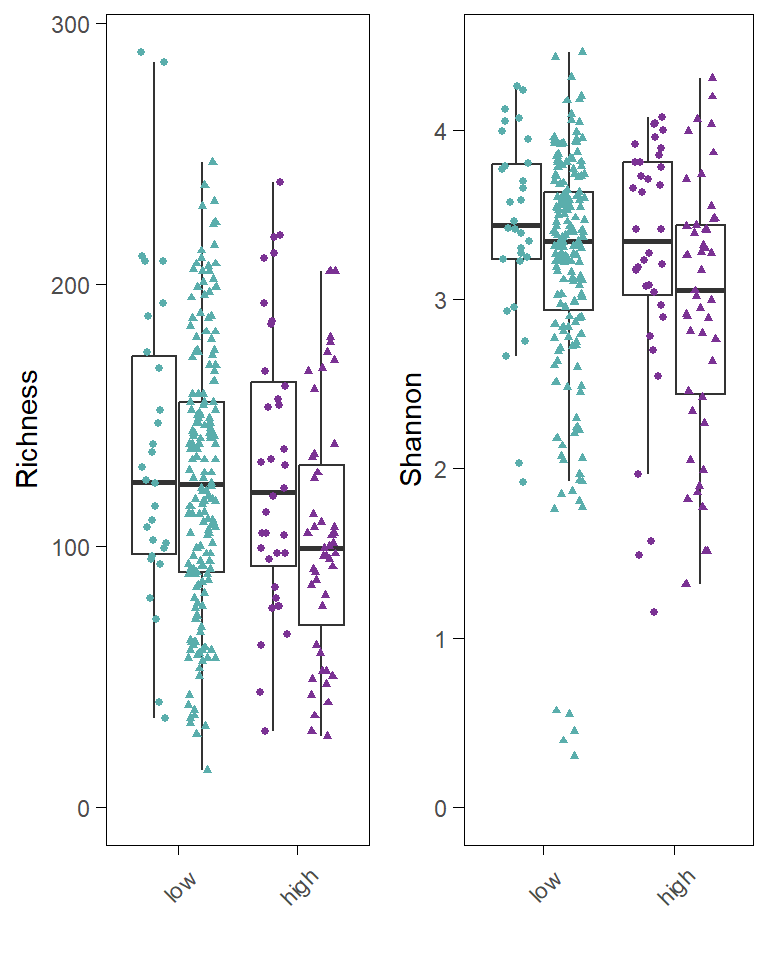

```r
alpha_div_plots[[paste(segment,"Country")]]
```